# p7 _version_prof

```python
import pandas as pd
dis_rev= pd.read_csv('D:\\Aopenclassroom\\p7\\donnees/dis_rev.csv',decimal=',')

indicateur= pd.read_csv('D:\\Aopenclassroom\\p7\\donnees/indicateur.csv')
pay_ind_gini= pd.read_csv('D:\\Aopenclassroom\\p7\\donnees/pay_ind_gini.csv')
```

```python
api_pov_geni= pd.read_csv('D:\\Aopenclassroom\\p7\\donnees/api_pov_geni.csv')
elas= pd.read_csv('D:\\Aopenclassroom\\p7\\donnees/parent.csv')
```

```python
pop=pd.read_csv('D:\\Aopenclassroom\\p7\\donnees/population.csv')
```

```python
world_inc_dis=pd.read_csv('D:\\Aopenclassroom\\p7\\donnees\\projet_7/world_income_distribution.csv')
```

```python
dis_rev
```

|  | country | year_survey | quantile | nb_quantiles | income | gdpppp |
| --- | --- | --- | --- | --- | --- | --- |
| 0 | ALB | 2008 | 1 | 100 | 728.89795 | 7297.00000 |
| 1 | ALB | 2008 | 2 | 100 | 916.66235 | 7297.00000 |
| 2 | ALB | 2008 | 3 | 100 | 1010.91600 | 7297.00000 |
| 3 | ALB | 2008 | 4 | 100 | 1086.90780 | 7297.00000 |
| 4 | ALB | 2008 | 5 | 100 | 1132.69970 | 7297.00000 |
| ... | ... | ... | ... | ... | ... | ... |
| 11594 | COD | 2008 | 96 | 100 | 810.62330 | 303.19305 |
| 11595 | COD | 2008 | 97 | 100 | 911.78340 | 303.19305 |
| 11596 | COD | 2008 | 98 | 100 | 1057.80740 | 303.19305 |
| 11597 | COD | 2008 | 99 | 100 | 1286.60290 | 303.19305 |
| 11598 | COD | 2008 | 100 | 100 | 2243.12260 | 303.19305 |

11599 rows × 6 columns

```python
world_inc_dis
```

|  | country | year_survey | quantile | nb_quantiles | income | pop | gdpppp |
| --- | --- | --- | --- | --- | --- | --- | --- |
| 0 | ALB | 2008 | 1 | 100 | 728.89795 | 0.031430 | 7297.00000 |
| 1 | ALB | 2008 | 2 | 100 | 916.66235 | 0.031430 | 7297.00000 |
| 2 | ALB | 2008 | 3 | 100 | 1010.91600 | 0.031430 | 7297.00000 |
| 3 | ALB | 2008 | 4 | 100 | 1086.90780 | 0.031430 | 7297.00000 |
| 4 | ALB | 2008 | 5 | 100 | 1132.69970 | 0.031430 | 7297.00000 |
| ... | ... | ... | ... | ... | ... | ... | ... |
| 11594 | COD | 2008 | 96 | 100 | 810.62330 | 0.624749 | 303.19305 |
| 11595 | COD | 2008 | 97 | 100 | 911.78340 | 0.624749 | 303.19305 |
| 11596 | COD | 2008 | 98 | 100 | 1057.80740 | 0.624749 | 303.19305 |
| 11597 | COD | 2008 | 99 | 100 | 1286.60290 | 0.624749 | 303.19305 |
| 11598 | COD | 2008 | 100 | 100 | 2243.12260 | 0.624749 | 303.19305 |

11599 rows × 7 columns

# Netoyage des données

```python
pay_ind_gini
```

|  | Country Code | Region | IncomeGroup | SpecialNotes | TableName | Unnamed: 5 |
| --- | --- | --- | --- | --- | --- | --- |
| 0 | ABW | Latin America & Caribbean | High income | NaN | Aruba | NaN |
| 1 | AFE | NaN | NaN | 26 countries, stretching from the Red Sea in t... | Africa Eastern and Southern | NaN |
| 2 | AFG | South Asia | Low income | The reporting period for national accounts dat... | Afghanistan | NaN |
| 3 | AFW | NaN | NaN | 22 countries, stretching from the westernmost ... | Africa Western and Central | NaN |
| 4 | AGO | Sub-Saharan Africa | Lower middle income | NaN | Angola | NaN |
| ... | ... | ... | ... | ... | ... | ... |
| 260 | XKX | Europe & Central Asia | Upper middle income | NaN | Kosovo | NaN |
| 261 | YEM | Middle East & North Africa | Low income | The World Bank systematically assesses the app... | Yemen, Rep. | NaN |
| 262 | ZAF | Sub-Saharan Africa | Upper middle income | Fiscal year end: March 31; reporting period fo... | South Africa | NaN |
| 263 | ZMB | Sub-Saharan Africa | Lower middle income | National accounts data were rebased to reflect... | Zambia | NaN |
| 264 | ZWE | Sub-Saharan Africa | Lower middle income | National Accounts data are reported in Zimbabw... | Zimbabwe | NaN |

265 rows × 6 columns

### verifier les données de la table population

```python
pop.head()
```

|  | Country Name | Country Code | Indicator Name | Indicator Code | 1960 | 1961 | 1962 | 1963 | 1964 | 1965 | ... | 2012 | 2013 | 2014 | 2015 | 2016 | 2017 | 2018 | 2019 | 2020 | Unnamed: 65 |
| --- | --- | --- | --- | --- | --- | --- | --- | --- | --- | --- | --- | --- | --- | --- | --- | --- | --- | --- | --- | --- | --- |
| 0 | Aruba | ABW | Population, total | SP.POP.TOTL | 54208.0 | 55434.0 | 56234.0 | 56699.0 | 57029.0 | 57357.0 | ... | 102565.0 | 103165.0 | 103776.0 | 104339.0 | 104865.0 | 105361.0 | 105846.0 | 106310.0 | 106766.0 | NaN |
| 1 | Africa Eastern and Southern | AFE | Population, total | SP.POP.TOTL | 130836765.0 | 134159786.0 | 137614644.0 | 141202036.0 | 144920186.0 | 148769974.0 | ... | 547482863.0 | 562601578.0 | 578075373.0 | 593871847.0 | 609978946.0 | 626392880.0 | 643090131.0 | 660046272.0 | 677243299.0 | NaN |
| 2 | Afghanistan | AFG | Population, total | SP.POP.TOTL | 8996967.0 | 9169406.0 | 9351442.0 | 9543200.0 | 9744772.0 | 9956318.0 | ... | 31161378.0 | 32269592.0 | 33370804.0 | 34413603.0 | 35383028.0 | 36296111.0 | 37171922.0 | 38041757.0 | 38928341.0 | NaN |
| 3 | Africa Western and Central | AFW | Population, total | SP.POP.TOTL | 96396419.0 | 98407221.0 | 100506960.0 | 102691339.0 | 104953470.0 | 107289875.0 | ... | 370243017.0 | 380437896.0 | 390882979.0 | 401586651.0 | 412551299.0 | 423769930.0 | 435229381.0 | 446911598.0 | 458803476.0 | NaN |
| 4 | Angola | AGO | Population, total | SP.POP.TOTL | 5454938.0 | 5531451.0 | 5608499.0 | 5679409.0 | 5734995.0 | 5770573.0 | ... | 25107925.0 | 26015786.0 | 26941773.0 | 27884380.0 | 28842482.0 | 29816769.0 | 30809787.0 | 31825299.0 | 32866268.0 | NaN |

5 rows × 66 columns

```python
pop['Country Code'].unique().shape
```

```
(266,)
```

```python
population1=pop[['Country Name','Country Code','2008']]
population1
```

|  | Country Name | Country Code | 2008 |
| --- | --- | --- | --- |
| 0 | Aruba | ABW | 101362.0 |
| 1 | Africa Eastern and Southern | AFE | 491173160.0 |
| 2 | Afghanistan | AFG | 27722281.0 |
| 3 | Africa Western and Central | AFW | 331772330.0 |
| 4 | Angola | AGO | 21695636.0 |
| ... | ... | ... | ... |
| 261 | Kosovo | XKX | 1747383.0 |
| 262 | Yemen, Rep. | YEM | 21892149.0 |
| 263 | South Africa | ZAF | 49779472.0 |
| 264 | Zambia | ZMB | 12848531.0 |
| 265 | Zimbabwe | ZWE | 12379553.0 |

266 rows × 3 columns

```python
population1.isna().sum()
```

```
Country Name    0
Country Code    0
2008            1
dtype: int64
```

```python
population1[population1['2008'].isna()]
```

|  | Country Name | Country Code | 2008 |
| --- | --- | --- | --- |
| 110 | Not classified | INX | NaN |

```python
population=population1.dropna()
population
```

|  | Country Name | Country Code | 2008 |
| --- | --- | --- | --- |
| 0 | Aruba | ABW | 101362.0 |
| 1 | Africa Eastern and Southern | AFE | 491173160.0 |
| 2 | Afghanistan | AFG | 27722281.0 |
| 3 | Africa Western and Central | AFW | 331772330.0 |
| 4 | Angola | AGO | 21695636.0 |
| ... | ... | ... | ... |
| 261 | Kosovo | XKX | 1747383.0 |
| 262 | Yemen, Rep. | YEM | 21892149.0 |
| 263 | South Africa | ZAF | 49779472.0 |
| 264 | Zambia | ZMB | 12848531.0 |
| 265 | Zimbabwe | ZWE | 12379553.0 |

265 rows × 3 columns

```python
population.isnull().sum()
```

```
Country Name    0
Country Code    0
2008            0
dtype: int64
```

```python
#population.describe(include='all')
```

```python
population.loc[population['Country Code'].duplicated(keep=False),:]
```

|  | Country Name | Country Code | 2008 |
| --- | --- | --- | --- |

```python
dis_rev
```

|  | country | year_survey | quantile | nb_quantiles | income | gdpppp |
| --- | --- | --- | --- | --- | --- | --- |
| 0 | ALB | 2008 | 1 | 100 | 728.89795 | 7297.00000 |
| 1 | ALB | 2008 | 2 | 100 | 916.66235 | 7297.00000 |
| 2 | ALB | 2008 | 3 | 100 | 1010.91600 | 7297.00000 |
| 3 | ALB | 2008 | 4 | 100 | 1086.90780 | 7297.00000 |
| 4 | ALB | 2008 | 5 | 100 | 1132.69970 | 7297.00000 |
| ... | ... | ... | ... | ... | ... | ... |
| 11594 | COD | 2008 | 96 | 100 | 810.62330 | 303.19305 |
| 11595 | COD | 2008 | 97 | 100 | 911.78340 | 303.19305 |
| 11596 | COD | 2008 | 98 | 100 | 1057.80740 | 303.19305 |
| 11597 | COD | 2008 | 99 | 100 | 1286.60290 | 303.19305 |
| 11598 | COD | 2008 | 100 | 100 | 2243.12260 | 303.19305 |

11599 rows × 6 columns

```python
dis_rev
```

|  | country | year_survey | quantile | nb_quantiles | income | gdpppp |
| --- | --- | --- | --- | --- | --- | --- |
| 0 | ALB | 2008 | 1 | 100 | 728.89795 | 7297.00000 |
| 1 | ALB | 2008 | 2 | 100 | 916.66235 | 7297.00000 |
| 2 | ALB | 2008 | 3 | 100 | 1010.91600 | 7297.00000 |
| 3 | ALB | 2008 | 4 | 100 | 1086.90780 | 7297.00000 |
| 4 | ALB | 2008 | 5 | 100 | 1132.69970 | 7297.00000 |
| ... | ... | ... | ... | ... | ... | ... |
| 11594 | COD | 2008 | 96 | 100 | 810.62330 | 303.19305 |
| 11595 | COD | 2008 | 97 | 100 | 911.78340 | 303.19305 |
| 11596 | COD | 2008 | 98 | 100 | 1057.80740 | 303.19305 |
| 11597 | COD | 2008 | 99 | 100 | 1286.60290 | 303.19305 |
| 11598 | COD | 2008 | 100 | 100 | 2243.12260 | 303.19305 |

11599 rows × 6 columns

```python
dis_rev.year_survey.unique()
```

```
array([2008, 2009, 2010, 2007, 2006, 2011, 2004], dtype=int64)
```

```python
population
```

|  | Country Name | Country Code | 2008 |
| --- | --- | --- | --- |
| 0 | Aruba | ABW | 101362.0 |
| 1 | Africa Eastern and Southern | AFE | 491173160.0 |
| 2 | Afghanistan | AFG | 27722281.0 |
| 3 | Africa Western and Central | AFW | 331772330.0 |
| 4 | Angola | AGO | 21695636.0 |
| ... | ... | ... | ... |
| 261 | Kosovo | XKX | 1747383.0 |
| 262 | Yemen, Rep. | YEM | 21892149.0 |
| 263 | South Africa | ZAF | 49779472.0 |
| 264 | Zambia | ZMB | 12848531.0 |
| 265 | Zimbabwe | ZWE | 12379553.0 |

265 rows × 3 columns

```python
dis_rev.describe()
```

|  | year_survey | quantile | nb_quantiles | income | gdpppp |
| --- | --- | --- | --- | --- | --- |
| count | 11599.000000 | 11599.000000 | 11599.0 | 11599.000000 | 1.139900e+04 |
| mean | 2007.982757 | 50.500819 | 100.0 | 6069.224260 | 5.022128e+04 |
| std | 0.909633 | 28.868424 | 0.0 | 9414.185972 | 4.000688e+05 |
| min | 2004.000000 | 1.000000 | 100.0 | 16.719418 | 3.031931e+02 |
| 25% | 2008.000000 | 25.500000 | 100.0 | 900.685515 | 2.576000e+03 |
| 50% | 2008.000000 | 51.000000 | 100.0 | 2403.244900 | 7.560000e+03 |
| 75% | 2008.000000 | 75.500000 | 100.0 | 7515.420900 | 1.877300e+04 |
| max | 2011.000000 | 100.000000 | 100.0 | 176928.550000 | 4.300332e+06 |

ici on remarque qu on 2008 on a plus de nombre de quantile donc je choisis 2008 ou il y a le plus d informations

```python
dis_rev.isna().sum()
```

```
country           0
year_survey       0
quantile          0
nb_quantiles      0
income            0
gdpppp          200
dtype: int64
```

```python
dis_rev.isnull().sum()
```

```
country           0
year_survey       0
quantile          0
nb_quantiles      0
income            0
gdpppp          200
dtype: int64
```

#on remarque q'il manque donnee gdpppp

```python
#Vérification des valeurs manquantes sur la Series 'gdpppp' et 'population'
g=dis_rev.loc[dis_rev['gdpppp'].isna()==True]
g['country'].unique()
```

```
array(['XKX', 'PSE'], dtype=object)
```

```python
api_pov_geni.loc[(api_pov_geni['Country Code']=='XKX') ]
```

|  | Country Name | Country Code | Indicator Name | Indicator Code | 1960 | 1961 | 1962 | 1963 | 1964 | 1965 | ... | 2012 | 2013 | 2014 | 2015 | 2016 | 2017 | 2018 | 2019 | 2020 | Unnamed: 65 |
| --- | --- | --- | --- | --- | --- | --- | --- | --- | --- | --- | --- | --- | --- | --- | --- | --- | --- | --- | --- | --- | --- |
| 261 | Kosovo | XKX | Gini index | SI.POV.GINI | NaN | NaN | NaN | NaN | NaN | NaN | ... | 29.0 | 26.3 | 27.3 | 26.5 | 26.7 | 29.0 | NaN | NaN | NaN | NaN |

1 rows × 66 columns

```python
api_pov_geni.loc[api_pov_geni['Country Code']=='PSE']
```

|  | Country Name | Country Code | Indicator Name | Indicator Code | 1960 | 1961 | 1962 | 1963 | 1964 | 1965 | ... | 2012 | 2013 | 2014 | 2015 | 2016 | 2017 | 2018 | 2019 | 2020 | Unnamed: 65 |
| --- | --- | --- | --- | --- | --- | --- | --- | --- | --- | --- | --- | --- | --- | --- | --- | --- | --- | --- | --- | --- | --- |
| 196 | West Bank and Gaza | PSE | Gini index | SI.POV.GINI | NaN | NaN | NaN | NaN | NaN | NaN | ... | NaN | NaN | NaN | NaN | 33.7 | NaN | NaN | NaN | NaN | NaN |

1 rows × 66 columns

```python
#https://data.worldbank.org/indicator/NY.GDP.PCAP.PP.CD?locations=PS

dis_rev.loc[(dis_rev['country']=='XKX'),'gdpppp']=3708.7
```

```python
dis_rev.loc[(dis_rev['country']=='PSE'),'gdpppp']=6539.2
```

```python
dis_rev.loc[(dis_rev['country']=='XKX')].head(3)
```

|  | country | year_survey | quantile | nb_quantiles | income | gdpppp |
| --- | --- | --- | --- | --- | --- | --- |
| 5800 | XKX | 2008 | 1 | 100 | 437.89370 | 3708.7 |
| 5801 | XKX | 2008 | 2 | 100 | 508.17133 | 3708.7 |
| 5802 | XKX | 2008 | 3 | 100 | 591.82820 | 3708.7 |

```python
api_pov_geni.loc[api_pov_geni['Country Code']=='PSE']
```

|  | Country Name | Country Code | Indicator Name | Indicator Code | 1960 | 1961 | 1962 | 1963 | 1964 | 1965 | ... | 2012 | 2013 | 2014 | 2015 | 2016 | 2017 | 2018 | 2019 | 2020 | Unnamed: 65 |
| --- | --- | --- | --- | --- | --- | --- | --- | --- | --- | --- | --- | --- | --- | --- | --- | --- | --- | --- | --- | --- | --- |
| 196 | West Bank and Gaza | PSE | Gini index | SI.POV.GINI | NaN | NaN | NaN | NaN | NaN | NaN | ... | NaN | NaN | NaN | NaN | 33.7 | NaN | NaN | NaN | NaN | NaN |

1 rows × 66 columns

```python
dis_rev.info()
```

```
<class 'pandas.core.frame.DataFrame'>
RangeIndex: 11599 entries, 0 to 11598
Data columns (total 6 columns):
 #   Column        Non-Null Count  Dtype
---  ------        --------------  -----
 0   country       11599 non-null  object
 1   year_survey   11599 non-null  int64
 2   quantile      11599 non-null  int64
 3   nb_quantiles  11599 non-null  int64
 4   income        11599 non-null  float64
 5   gdpppp        11599 non-null  float64
dtypes: float64(2), int64(3), object(1)
memory usage: 543.8+ KB
```

```python
dis_rev.nunique()
```

```
country           116
year_survey         7
quantile          100
nb_quantiles        1
income          11598
gdpppp            116
dtype: int64
```

```python
dis_rev.year_survey.nunique()
```

```
7
```

```python
dis_rev.groupby(by='year_survey').nunique()
```

| year_survey | country | quantile | nb_quantiles | income | gdpppp |
| --- | --- | --- | --- | --- | --- |
| 2004 | 1 | 100 | 1 | 100 | 1 |
| 2006 | 5 | 100 | 1 | 500 | 5 |
| 2007 | 15 | 100 | 1 | 1500 | 15 |
| 2008 | 76 | 100 | 1 | 7598 | 76 |
| 2009 | 12 | 100 | 1 | 1200 | 12 |
| 2010 | 6 | 100 | 1 | 600 | 6 |
| 2011 | 1 | 100 | 1 | 100 | 1 |

```python
dis_rev.loc[dis_rev.duplicated(keep=False),:]
```

|  | country | year_survey | quantile | nb_quantiles | income | gdpppp |
| --- | --- | --- | --- | --- | --- | --- |

```python
dis_rev.country.unique()
```

```
array(['ALB', 'ARG', 'ARM', 'AUT', 'AZE', 'BEL', 'BFA', 'BGD', 'BGR',
       'BIH', 'BLR', 'BOL', 'BRA', 'BTN', 'CAF', 'CAN', 'CHL', 'CHN',
       'CIV', 'CMR', 'COL', 'CRI', 'CYP', 'CZE', 'DEU', 'DNK', 'DOM',
       'ECU', 'EGY', 'ESP', 'EST', 'FIN', 'FJI', 'FRA', 'GBR', 'GEO',
       'GHA', 'GIN', 'GRC', 'GTM', 'HND', 'HRV', 'HUN', 'IDN', 'IND',
       'IRL', 'IRN', 'IRQ', 'ISL', 'ISR', 'ITA', 'JOR', 'JPN', 'KAZ',
       'KEN', 'KGZ', 'KHM', 'KOR', 'XKX', 'LAO', 'LBR', 'LKA', 'LTU',
       'LUX', 'LVA', 'MAR', 'MDA', 'MDG', 'MEX', 'MKD', 'MLI', 'MNE',
       'MNG', 'MOZ', 'MRT', 'MWI', 'MYS', 'NER', 'NGA', 'NIC', 'NLD',
       'NOR', 'NPL', 'PAK', 'PAN', 'PER', 'PHL', 'POL', 'PRT', 'PRY',
       'ROU', 'RUS', 'SDN', 'SLV', 'SRB', 'SVK', 'SVN', 'SWE', 'SWZ',
       'SYR', 'THA', 'TJK', 'TLS', 'TUR', 'TWN', 'TZA', 'UGA', 'UKR',
       'URY', 'USA', 'VEN', 'VNM', 'PSE', 'YEM', 'ZAF', 'COD'],
      dtype=object)
```

```python
dis_rev.value_counts()
```

```
country  year_survey  quantile  nb_quantiles  income       gdpppp
ALB      2008         1         100           728.89795    7297.0    1
NER      2007         28        100           355.66820    631.0     1
                      30        100           365.56732    631.0     1
                      31        100           370.75150    631.0     1
                      32        100           378.85794    631.0     1
                                                                    ..
GIN      2007         68        100           714.20410    977.0     1
                      69        100           729.34070    977.0     1
                      70        100           744.18410    977.0     1
                      71        100           758.38556    977.0     1
ZAF      2008         100       100           82408.55000  9602.0    1
Length: 11599, dtype: int64
```

```python
dis_rev.nb_quantiles
```

```
0        100
1        100
2        100
3        100
4        100
        ...
11594    100
11595    100
11596    100
11597    100
11598    100
Name: nb_quantiles, Length: 11599, dtype: int64
```

```python
dis_rev_sum=dis_rev.groupby(['country']).sum()
 #dis_rev_2008.groupby(["country"])['income'].agg('sum')
dis_rev_sum
```

| country | year_survey | quantile | nb_quantiles | income | gdpppp |
| --- | --- | --- | --- | --- | --- |
| ALB | 200800 | 5050 | 10000 | 2.994830e+05 | 729700.0 |
| ARG | 200800 | 5050 | 10000 | 5.847885e+05 | 1322000.0 |
| ARM | 200800 | 5050 | 10000 | 1.628383e+05 | 561100.0 |
| AUT | 200800 | 5050 | 10000 | 1.663760e+06 | 3619300.0 |
| AZE | 200800 | 5050 | 10000 | 2.357429e+05 | 810100.0 |
| ... | ... | ... | ... | ... | ... |
| VEN | 200600 | 5050 | 10000 | 3.167148e+05 | 1175600.0 |
| VNM | 200600 | 5050 | 10000 | 1.377774e+05 | 257800.0 |
| XKX | 200800 | 5050 | 10000 | 2.176269e+05 | 370870.0 |
| YEM | 200800 | 5050 | 10000 | 1.042636e+05 | 222400.0 |
| ZAF | 200800 | 5050 | 10000 | 5.617905e+05 | 960200.0 |

116 rows × 5 columns

```python
dis_rev_sum.info()
```

```
<class 'pandas.core.frame.DataFrame'>
Index: 116 entries, ALB to ZAF
Data columns (total 5 columns):
 #   Column        Non-Null Count  Dtype
---  ------        --------------  -----
 0   year_survey   116 non-null    int64
 1   quantile      116 non-null    int64
 2   nb_quantiles  116 non-null    int64
 3   income        116 non-null    float64
 4   gdpppp        116 non-null    float64
dtypes: float64(2), int64(3)
memory usage: 5.4+ KB
```

```python
dis_rev_sum.describe(include='all')
```

|  | year_survey | quantile | nb_quantiles | income | gdpppp |
| --- | --- | --- | --- | --- | --- |
| count | 116.000000 | 116.000000 | 116.000000 | 1.160000e+02 | 1.160000e+02 |
| mean | 200780.965517 | 5049.646552 | 9999.137931 | 6.068701e+05 | 4.943941e+06 |
| std | 207.469974 | 3.806754 | 9.284767 | 6.660933e+05 | 3.983345e+07 |
| min | 198792.000000 | 5009.000000 | 9900.000000 | 2.760160e+04 | 3.031931e+04 |
| 25% | 200800.000000 | 5050.000000 | 10000.000000 | 1.374270e+05 | 2.577500e+05 |
| 50% | 200800.000000 | 5050.000000 | 10000.000000 | 3.287175e+05 | 7.532500e+05 |
| 75% | 200800.000000 | 5050.000000 | 10000.000000 | 7.077900e+05 | 1.819625e+06 |
| max | 201100.000000 | 5050.000000 | 10000.000000 | 2.688851e+06 | 4.300332e+08 |

ici on remarque que le nombre de quantil n est pas le méme dans tout les pays

```python
dis_rev_sum.loc[dis_rev_sum.nb_quantiles<10000]
```

| country | year_survey | quantile | nb_quantiles | income | gdpppp |
| --- | --- | --- | --- | --- | --- |
| LTU | 198792 | 5009 | 9900 | 657483.5158 | 1739529.0 |

```python
dis_ltu=dis_rev[dis_rev['country']=='LTU']
```

```python
dis_ltu.head()
```

|  | country | year_survey | quantile | nb_quantiles | income | gdpppp |
| --- | --- | --- | --- | --- | --- | --- |
| 6200 | LTU | 2008 | 1 | 100 | 566.3453 | 17571.0 |
| 6201 | LTU | 2008 | 2 | 100 | 1147.0587 | 17571.0 |
| 6202 | LTU | 2008 | 3 | 100 | 1490.8408 | 17571.0 |
| 6203 | LTU | 2008 | 4 | 100 | 1746.5715 | 17571.0 |
| 6204 | LTU | 2008 | 5 | 100 | 1842.9542 | 17571.0 |

```python
dis_ltu['quantile'].count()
```

```
99
```

```python
l_q=dis_ltu['quantile'].unique().tolist()
```

```python
d_q=dis_rev[~dis_rev['quantile'].isin(l_q)]
d_q
```

|  | country | year_survey | quantile | nb_quantiles | income | gdpppp |
| --- | --- | --- | --- | --- | --- | --- |
| 40 | ALB | 2008 | 41 | 100 | 2216.39600 | 7297.00000 |
| 140 | ARG | 2008 | 41 | 100 | 3405.53340 | 13220.00000 |
| 240 | ARM | 2008 | 41 | 100 | 1281.83940 | 5611.00000 |
| 340 | AUT | 2008 | 41 | 100 | 13065.98600 | 36193.00000 |
| 440 | AZE | 2008 | 41 | 100 | 1730.64820 | 8101.00000 |
| ... | ... | ... | ... | ... | ... | ... |
| 11139 | VNM | 2006 | 41 | 100 | 897.99164 | 2578.00000 |
| 11239 | PSE | 2009 | 41 | 100 | 755.75820 | 6539.20000 |
| 11339 | YEM | 2008 | 41 | 100 | 689.55950 | 2224.00000 |
| 11439 | ZAF | 2008 | 41 | 100 | 1493.57540 | 9602.00000 |
| 11539 | COD | 2008 | 41 | 100 | 156.95894 | 303.19305 |

115 rows × 6 columns

```python
dis_ltu['quantile'].unique()
```

```
array([  1,   2,   3,   4,   5,   6,   7,   8,   9,  10,  11,  12,  13,
        14,  15,  16,  17,  18,  19,  20,  21,  22,  23,  24,  25,  26,
        27,  28,  29,  30,  31,  32,  33,  34,  35,  36,  37,  38,  39,
        40,  42,  43,  44,  45,  46,  47,  48,  49,  50,  51,  52,  53,
        54,  55,  56,  57,  58,  59,  60,  61,  62,  63,  64,  65,  66,
        67,  68,  69,  70,  71,  72,  73,  74,  75,  76,  77,  78,  79,
        80,  81,  82,  83,  84,  85,  86,  87,  88,  89,  90,  91,  92,
        93,  94,  95,  96,  97,  98,  99, 100], dtype=int64)
```

ici on trouve qu'il manque le quantile 41 on retourne sur la table pour compléter le quantile manquant

```python
dis_rev[(dis_rev['country']=='LTU')&(dis_rev['nb_quantiles']==0)]
```

|  | country | year_survey | quantile | nb_quantiles | income | gdpppp |
| --- | --- | --- | --- | --- | --- | --- |

```python
#on recupére l index
dis_rev_ind=dis_rev[(dis_rev['quantile']==40)&(dis_rev['country']=='LTU')]
dis_rev_ind
```

|  | country | year_survey | quantile | nb_quantiles | income | gdpppp |
| --- | --- | --- | --- | --- | --- | --- |
| 6239 | LTU | 2008 | 40 | 100 | 4868.4507 | 17571.0 |

```python
dis_rev.income[6239:6240]
```

```
6239    4868.4507
Name: income, dtype: float64
```

```python
dis_rev.income[6239:6240].mean()
```

```
4868.4507
```

```python
dis_rev = dis_rev.append(
    {'country' : 'LTU' ,
     'year_survey' : 2008,
     'quantile': 41,
     'nb_quantiles': 100,
     'income': 4373.59275,
     'gdpppp': 17571.0,
    } ,ignore_index=True)
```

```python
#df = df.append(pd.DataFrame([new_row],index=['e'],columns=df.columns))
```

```python
dis_rev['country'].unique().shape
```

```
(116,)
```

```python
dis_rev_sum2=pd.DataFrame(dis_rev.groupby(['country']).sum())
 #dis_rev_2008.groupby(["country"])['income'].agg('sum')
dis_rev_sum2
```

| country | year_survey | quantile | nb_quantiles | income | gdpppp |
| --- | --- | --- | --- | --- | --- |
| ALB | 200800 | 5050 | 10000 | 2.994830e+05 | 729700.0 |
| ARG | 200800 | 5050 | 10000 | 5.847885e+05 | 1322000.0 |
| ARM | 200800 | 5050 | 10000 | 1.628383e+05 | 561100.0 |
| AUT | 200800 | 5050 | 10000 | 1.663760e+06 | 3619300.0 |
| AZE | 200800 | 5050 | 10000 | 2.357429e+05 | 810100.0 |
| ... | ... | ... | ... | ... | ... |
| VEN | 200600 | 5050 | 10000 | 3.167148e+05 | 1175600.0 |
| VNM | 200600 | 5050 | 10000 | 1.377774e+05 | 257800.0 |
| XKX | 200800 | 5050 | 10000 | 2.176269e+05 | 370870.0 |
| YEM | 200800 | 5050 | 10000 | 1.042636e+05 | 222400.0 |
| ZAF | 200800 | 5050 | 10000 | 5.617905e+05 | 960200.0 |

116 rows × 5 columns

```python
population
```

|  | Country Name | Country Code | 2008 |
| --- | --- | --- | --- |
| 0 | Aruba | ABW | 101362.0 |
| 1 | Africa Eastern and Southern | AFE | 491173160.0 |
| 2 | Afghanistan | AFG | 27722281.0 |
| 3 | Africa Western and Central | AFW | 331772330.0 |
| 4 | Angola | AGO | 21695636.0 |
| ... | ... | ... | ... |
| 261 | Kosovo | XKX | 1747383.0 |
| 262 | Yemen, Rep. | YEM | 21892149.0 |
| 263 | South Africa | ZAF | 49779472.0 |
| 264 | Zambia | ZMB | 12848531.0 |
| 265 | Zimbabwe | ZWE | 12379553.0 |

265 rows × 3 columns

## population couverte par l'analyse (en termes de pourcentage de la population mondiale).

```python
pays=dis_rev.country.unique()
```

```python
pop_dis_rev=population.loc[population['Country Code'].isin (pays) ]
```

```python
pop_dis_rev
```

|  | Country Name | Country Code | 2008 |
| --- | --- | --- | --- |
| 5 | Albania | ALB | 2947314.0 |
| 9 | Argentina | ARG | 40080159.0 |
| 10 | Armenia | ARM | 2907615.0 |
| 14 | Austria | AUT | 8321496.0 |
| 15 | Azerbaijan | AZE | 8763400.0 |
| ... | ... | ... | ... |
| 254 | Venezuela, RB | VEN | 27635827.0 |
| 257 | Vietnam | VNM | 86243424.0 |
| 261 | Kosovo | XKX | 1747383.0 |
| 262 | Yemen, Rep. | YEM | 21892149.0 |
| 263 | South Africa | ZAF | 49779472.0 |

115 rows × 3 columns

```python
tot_pop=population['2008'].sum()
tot_pop
```

```
72109715796.0
```

```python
tot_pop_dis=pop_dis_rev['2008'].sum()
tot_pop_dis
```

```
6180824944.0
```

```python
pop_analyse=tot_pop_dis*100/tot_pop
print('population couverte par l\'analyse est:',pop_analyse,'%')
```

```
population couverte par l'analyse est: 8.57141770116761 %
```

```python
#on joint les deux tables population et distribution des revenues
#pop_rev=population.merge(dis_rev_sum2,
                         #left_on=['Country Code'],
                         #right_on=['country'])
```

```python
api_pov_geni.head()
```

|  | Country Name | Country Code | Indicator Name | Indicator Code | 1960 | 1961 | 1962 | 1963 | 1964 | 1965 | ... | 2012 | 2013 | 2014 | 2015 | 2016 | 2017 | 2018 | 2019 | 2020 | Unnamed: 65 |
| --- | --- | --- | --- | --- | --- | --- | --- | --- | --- | --- | --- | --- | --- | --- | --- | --- | --- | --- | --- | --- | --- |
| 0 | Aruba | ABW | Gini index | SI.POV.GINI | NaN | NaN | NaN | NaN | NaN | NaN | ... | NaN | NaN | NaN | NaN | NaN | NaN | NaN | NaN | NaN | NaN |
| 1 | Africa Eastern and Southern | AFE | Gini index | SI.POV.GINI | NaN | NaN | NaN | NaN | NaN | NaN | ... | NaN | NaN | NaN | NaN | NaN | NaN | NaN | NaN | NaN | NaN |
| 2 | Afghanistan | AFG | Gini index | SI.POV.GINI | NaN | NaN | NaN | NaN | NaN | NaN | ... | NaN | NaN | NaN | NaN | NaN | NaN | NaN | NaN | NaN | NaN |
| 3 | Africa Western and Central | AFW | Gini index | SI.POV.GINI | NaN | NaN | NaN | NaN | NaN | NaN | ... | NaN | NaN | NaN | NaN | NaN | NaN | NaN | NaN | NaN | NaN |
| 4 | Angola | AGO | Gini index | SI.POV.GINI | NaN | NaN | NaN | NaN | NaN | NaN | ... | NaN | NaN | NaN | NaN | NaN | NaN | 51.3 | NaN | NaN | NaN |

5 rows × 66 columns

```python
api_pov_geni.describe()
```

|  | 1960 | 1961 | 1962 | 1963 | 1964 | 1965 | 1966 | 1967 | 1968 | 1969 | ... | 2012 | 2013 | 2014 | 2015 | 2016 | 2017 | 2018 | 2019 | 2020 | Unnamed: 65 |
| --- | --- | --- | --- | --- | --- | --- | --- | --- | --- | --- | --- | --- | --- | --- | --- | --- | --- | --- | --- | --- | --- |
| count | 0.0 | 0.0 | 0.0 | 0.0 | 0.0 | 0.0 | 0.0 | 1.0 | 0.0 | 1.0 | ... | 83.000000 | 76.000000 | 83.000000 | 83.000000 | 82.000000 | 76.000000 | 84.000000 | 58.000000 | 19.000000 | 0.0 |
| mean | NaN | NaN | NaN | NaN | NaN | NaN | NaN | 34.0 | NaN | 33.7 | ... | 36.277108 | 36.396053 | 36.519277 | 36.792771 | 36.210976 | 35.511842 | 35.732143 | 35.372414 | 39.668421 | NaN |
| std | NaN | NaN | NaN | NaN | NaN | NaN | NaN | NaN | NaN | NaN | ... | 7.291748 | 7.276161 | 7.979936 | 7.830005 | 7.475739 | 6.986329 | 6.881005 | 7.623666 | 8.730092 | NaN |
| min | NaN | NaN | NaN | NaN | NaN | NaN | NaN | 34.0 | NaN | 33.7 | ... | 24.700000 | 24.600000 | 24.000000 | 25.400000 | 24.800000 | 23.200000 | 24.600000 | 23.200000 | 24.400000 | NaN |
| 25% | NaN | NaN | NaN | NaN | NaN | NaN | NaN | 34.0 | NaN | 33.7 | ... | 30.050000 | 30.750000 | 31.050000 | 31.450000 | 31.200000 | 30.225000 | 30.175000 | 29.400000 | 34.750000 | NaN |
| 50% | NaN | NaN | NaN | NaN | NaN | NaN | NaN | 34.0 | NaN | 33.7 | ... | 35.400000 | 36.200000 | 35.100000 | 35.900000 | 34.900000 | 35.300000 | 35.250000 | 34.400000 | 42.300000 | NaN |
| 75% | NaN | NaN | NaN | NaN | NaN | NaN | NaN | 34.0 | NaN | 33.7 | ... | 41.150000 | 40.275000 | 40.850000 | 41.150000 | 40.975000 | 40.475000 | 39.900000 | 41.350000 | 45.150000 | NaN |
| max | NaN | NaN | NaN | NaN | NaN | NaN | NaN | 34.0 | NaN | 33.7 | ... | 53.400000 | 52.700000 | 63.000000 | 59.100000 | 54.600000 | 53.300000 | 53.900000 | 53.500000 | 54.200000 | NaN |

8 rows × 62 columns

```python
api_pov_geni.isnull().any()
```

```
Country Name      False
Country Code      False
Indicator Name    False
Indicator Code    False
1960               True
                  ...
2017               True
2018               True
2019               True
2020               True
Unnamed: 65        True
Length: 66, dtype: bool
```

```python
api_pov_geni.isna().any()
```

```
Country Name      False
Country Code      False
Indicator Name    False
Indicator Code    False
1960               True
                  ...
2017               True
2018               True
2019               True
2020               True
Unnamed: 65        True
Length: 66, dtype: bool
```

```python
print(api_pov_geni.columns)
```

```
Index(['Country Name', 'Country Code', 'Indicator Name', 'Indicator Code',
       '1960', '1961', '1962', '1963', '1964', '1965', '1966', '1967', '1968',
       '1969', '1970', '1971', '1972', '1973', '1974', '1975', '1976', '1977',
       '1978', '1979', '1980', '1981', '1982', '1983', '1984', '1985', '1986',
       '1987', '1988', '1989', '1990', '1991', '1992', '1993', '1994', '1995',
       '1996', '1997', '1998', '1999', '2000', '2001', '2002', '2003', '2004',
       '2005', '2006', '2007', '2008', '2009', '2010', '2011', '2012', '2013',
       '2014', '2015', '2016', '2017', '2018', '2019', '2020', 'Unnamed: 65'],
      dtype='object')
```

```python
api_pov_geni
```

|  | Country Name | Country Code | Indicator Name | Indicator Code | 1960 | 1961 | 1962 | 1963 | 1964 | 1965 | ... | 2012 | 2013 | 2014 | 2015 | 2016 | 2017 | 2018 | 2019 | 2020 | Unnamed: 65 |
| --- | --- | --- | --- | --- | --- | --- | --- | --- | --- | --- | --- | --- | --- | --- | --- | --- | --- | --- | --- | --- | --- |
| 0 | Aruba | ABW | Gini index | SI.POV.GINI | NaN | NaN | NaN | NaN | NaN | NaN | ... | NaN | NaN | NaN | NaN | NaN | NaN | NaN | NaN | NaN | NaN |
| 1 | Africa Eastern and Southern | AFE | Gini index | SI.POV.GINI | NaN | NaN | NaN | NaN | NaN | NaN | ... | NaN | NaN | NaN | NaN | NaN | NaN | NaN | NaN | NaN | NaN |
| 2 | Afghanistan | AFG | Gini index | SI.POV.GINI | NaN | NaN | NaN | NaN | NaN | NaN | ... | NaN | NaN | NaN | NaN | NaN | NaN | NaN | NaN | NaN | NaN |
| 3 | Africa Western and Central | AFW | Gini index | SI.POV.GINI | NaN | NaN | NaN | NaN | NaN | NaN | ... | NaN | NaN | NaN | NaN | NaN | NaN | NaN | NaN | NaN | NaN |
| 4 | Angola | AGO | Gini index | SI.POV.GINI | NaN | NaN | NaN | NaN | NaN | NaN | ... | NaN | NaN | NaN | NaN | NaN | NaN | 51.3 | NaN | NaN | NaN |
| ... | ... | ... | ... | ... | ... | ... | ... | ... | ... | ... | ... | ... | ... | ... | ... | ... | ... | ... | ... | ... | ... |
| 261 | Kosovo | XKX | Gini index | SI.POV.GINI | NaN | NaN | NaN | NaN | NaN | NaN | ... | 29.0 | 26.3 | 27.3 | 26.5 | 26.7 | 29.0 | NaN | NaN | NaN | NaN |
| 262 | Yemen, Rep. | YEM | Gini index | SI.POV.GINI | NaN | NaN | NaN | NaN | NaN | NaN | ... | NaN | NaN | 36.7 | NaN | NaN | NaN | NaN | NaN | NaN | NaN |
| 263 | South Africa | ZAF | Gini index | SI.POV.GINI | NaN | NaN | NaN | NaN | NaN | NaN | ... | NaN | NaN | 63.0 | NaN | NaN | NaN | NaN | NaN | NaN | NaN |
| 264 | Zambia | ZMB | Gini index | SI.POV.GINI | NaN | NaN | NaN | NaN | NaN | NaN | ... | NaN | NaN | NaN | 57.1 | NaN | NaN | NaN | NaN | NaN | NaN |
| 265 | Zimbabwe | ZWE | Gini index | SI.POV.GINI | NaN | NaN | NaN | NaN | NaN | NaN | ... | NaN | NaN | NaN | NaN | NaN | 44.3 | NaN | 50.3 | NaN | NaN |

266 rows × 66 columns

```python
api_pov_geni.isna().sum()
```

```
Country Name        0
Country Code        0
Indicator Name      0
Indicator Code      0
1960              266
                 ...
2017              190
2018              182
2019              208
2020              247
Unnamed: 65       266
Length: 66, dtype: int64
```

```python
api_pov_geni.value_counts
```

[output not shown]

[output cut: 25 more lines]

# Mission1

## année(s) des données utilisées:

année(s) des données utilisées:2008, 2009, 2010, 2007, 2006, 2011, 2004comment aficher le collones cachees?

```python
dis_rev.year_survey.unique()
```

```
array([2008, 2009, 2010, 2007, 2006, 2011, 2004], dtype=int64)
```

## nombre de pays présents:

```python
print('le nombre de pays présents est de :',dis_rev.country.unique().shape)
```

```
le nombre de pays présents est de : (116,)
```

population couverte par l'analyse (en termes de pourcentage de la population mondiale):

```python
dis_rev
```

|  | country | year_survey | quantile | nb_quantiles | income | gdpppp |
| --- | --- | --- | --- | --- | --- | --- |
| 0 | ALB | 2008 | 1 | 100 | 728.89795 | 7297.00000 |
| 1 | ALB | 2008 | 2 | 100 | 916.66235 | 7297.00000 |
| 2 | ALB | 2008 | 3 | 100 | 1010.91600 | 7297.00000 |
| 3 | ALB | 2008 | 4 | 100 | 1086.90780 | 7297.00000 |
| 4 | ALB | 2008 | 5 | 100 | 1132.69970 | 7297.00000 |
| ... | ... | ... | ... | ... | ... | ... |
| 11595 | COD | 2008 | 97 | 100 | 911.78340 | 303.19305 |
| 11596 | COD | 2008 | 98 | 100 | 1057.80740 | 303.19305 |
| 11597 | COD | 2008 | 99 | 100 | 1286.60290 | 303.19305 |
| 11598 | COD | 2008 | 100 | 100 | 2243.12260 | 303.19305 |
| 11599 | LTU | 2008 | 41 | 100 | 4373.59275 | 17571.00000 |

11600 rows × 6 columns

```python
dis_rev.isna().sum()
```

```
country         0
year_survey     0
quantile        0
nb_quantiles    0
income          0
gdpppp          0
dtype: int64
```

```python
dis_rev_2008=dis_rev.loc[dis_rev['year_survey']==2008,:]
dis_rev_2008.head()
```

|  | country | year_survey | quantile | nb_quantiles | income | gdpppp |
| --- | --- | --- | --- | --- | --- | --- |
| 0 | ALB | 2008 | 1 | 100 | 728.89795 | 7297.0 |
| 1 | ALB | 2008 | 2 | 100 | 916.66235 | 7297.0 |
| 2 | ALB | 2008 | 3 | 100 | 1010.91600 | 7297.0 |
| 3 | ALB | 2008 | 4 | 100 | 1086.90780 | 7297.0 |
| 4 | ALB | 2008 | 5 | 100 | 1132.69970 | 7297.0 |

```python
len(dis_rev_2008.country.unique())
```

```
76
```

Le pouvoir d'achat d’une quantité donnée d’argent dépend en effet du coût de la vie, c’est-à-dire du niveau général des prix. La PPA permet de mesurer combien une devise permet d’acheter de biens et services dans chacune des zones que l’on compare.

# Mission 2:

## Montrez la diversité des pays en termes de distribution de revenus à l'aide d'un graphique

Montrez la diversité des pays en termes de distribution de revenus à l'aide d'un graphique. Celui-ci représentera le revenu moyen (axe des ordonnées, sur une échelle logarithmique) de chacune des classes de revenus (axe des abscisses) pour 5 à 10 pays que vous aurez choisis pour montrer la diversité des cas.

```python
dis_rev_2008.head()
```

|  | country | year_survey | quantile | nb_quantiles | income | gdpppp |
| --- | --- | --- | --- | --- | --- | --- |
| 0 | ALB | 2008 | 1 | 100 | 728.89795 | 7297.0 |
| 1 | ALB | 2008 | 2 | 100 | 916.66235 | 7297.0 |
| 2 | ALB | 2008 | 3 | 100 | 1010.91600 | 7297.0 |
| 3 | ALB | 2008 | 4 | 100 | 1086.90780 | 7297.0 |
| 4 | ALB | 2008 | 5 | 100 | 1132.69970 | 7297.0 |

```python
#le choix des pays
dis_rev_2008.sort_values('gdpppp', ascending = False).head(2)
```

|  | country | year_survey | quantile | nb_quantiles | income | gdpppp |
| --- | --- | --- | --- | --- | --- | --- |
| 3200 | FJI | 2008 | 1 | 100 | 308.17334 | 4300332.0 |
| 3261 | FJI | 2008 | 62 | 100 | 1743.00440 | 4300332.0 |

```python
dis_rev_sum2.sort_values('gdpppp', ascending =True)
```

| country | year_survey | quantile | nb_quantiles | income | gdpppp |
| --- | --- | --- | --- | --- | --- |
| COD | 200800 | 5050 | 10000 | 2.760160e+04 | 3.031931e+04 |
| LBR | 200700 | 5050 | 10000 | 6.150073e+04 | 3.720000e+04 |
| NER | 200700 | 5050 | 10000 | 6.501294e+04 | 6.310000e+04 |
| CAF | 200800 | 5050 | 10000 | 8.112999e+04 | 6.850000e+04 |
| MWI | 201000 | 5050 | 10000 | 9.142654e+04 | 7.288116e+04 |
| ... | ... | ... | ... | ... | ... |
| IRL | 200800 | 5050 | 10000 | 1.771074e+06 | 3.926800e+06 |
| USA | 200800 | 5050 | 10000 | 2.550358e+06 | 4.326100e+06 |
| NOR | 200800 | 5050 | 10000 | 2.248338e+06 | 4.907000e+06 |
| LUX | 200800 | 5050 | 10000 | 2.521756e+06 | 7.312700e+06 |
| FJI | 200800 | 5050 | 10000 | 2.098731e+05 | 4.300332e+08 |

116 rows × 5 columns

```python
dis_rev_2008.describe()
```

|  | year_survey | quantile | nb_quantiles | income | gdpppp |
| --- | --- | --- | --- | --- | --- |
| count | 7600.0 | 7600.000000 | 7600.0 | 7600.000000 | 7.600000e+03 |
| mean | 2008.0 | 50.500000 | 100.0 | 8315.428519 | 7.347645e+04 |
| std | 0.0 | 28.867969 | 0.0 | 10717.364597 | 4.883061e+05 |
| min | 2008.0 | 1.000000 | 100.0 | 17.317732 | 3.031931e+02 |
| 25% | 2008.0 | 25.750000 | 100.0 | 1709.574525 | 6.608250e+03 |
| 50% | 2008.0 | 50.500000 | 100.0 | 4539.301000 | 1.194850e+04 |
| 75% | 2008.0 | 75.250000 | 100.0 | 11457.519750 | 2.744025e+04 |
| max | 2008.0 | 100.000000 | 100.0 | 176928.550000 | 4.300332e+06 |

```python
dis_rev_sum2[38:39]
```

| country | year_survey | quantile | nb_quantiles | income | gdpppp |
| --- | --- | --- | --- | --- | --- |
| GIN | 200700 | 5050 | 10000 | 69601.20133 | 97700.0 |

```python
dis_rev_2008['income'].max()
```

```
176928.55
```

```python
dis_rev_2008[dis_rev_2008['income']==17.317732]
```

|  | country | year_survey | quantile | nb_quantiles | income | gdpppp |
| --- | --- | --- | --- | --- | --- | --- |
| 5700 | KOR | 2008 | 1 | 100 | 17.317732 | 19162.0 |

```python
dis_rev_2008[dis_rev_2008['income']==176928.55]
```

|  | country | year_survey | quantile | nb_quantiles | income | gdpppp |
| --- | --- | --- | --- | --- | --- | --- |
| 10998 | USA | 2008 | 100 | 100 | 176928.55 | 43261.0 |

```python
pay_ind_gini
```

|  | Country Code | Region | IncomeGroup | SpecialNotes | TableName | Unnamed: 5 |
| --- | --- | --- | --- | --- | --- | --- |
| 0 | ABW | Latin America & Caribbean | High income | NaN | Aruba | NaN |
| 1 | AFE | NaN | NaN | 26 countries, stretching from the Red Sea in t... | Africa Eastern and Southern | NaN |
| 2 | AFG | South Asia | Low income | The reporting period for national accounts dat... | Afghanistan | NaN |
| 3 | AFW | NaN | NaN | 22 countries, stretching from the westernmost ... | Africa Western and Central | NaN |
| 4 | AGO | Sub-Saharan Africa | Lower middle income | NaN | Angola | NaN |
| ... | ... | ... | ... | ... | ... | ... |
| 260 | XKX | Europe & Central Asia | Upper middle income | NaN | Kosovo | NaN |
| 261 | YEM | Middle East & North Africa | Low income | The World Bank systematically assesses the app... | Yemen, Rep. | NaN |
| 262 | ZAF | Sub-Saharan Africa | Upper middle income | Fiscal year end: March 31; reporting period fo... | South Africa | NaN |
| 263 | ZMB | Sub-Saharan Africa | Lower middle income | National accounts data were rebased to reflect... | Zambia | NaN |
| 264 | ZWE | Sub-Saharan Africa | Lower middle income | National Accounts data are reported in Zimbabw... | Zimbabwe | NaN |

265 rows × 6 columns

```python
#pays eyant un faible revenue

pay_ind_gini_low=pay_ind_gini[pay_ind_gini['IncomeGroup']=='Low income']

pay_ind_gini_low['Country Code'].unique()
```

```
array(['AFG', 'BDI', 'BFA', 'CAF', 'COD', 'ERI', 'ETH', 'GIN', 'GMB',
       'GNB', 'LBR', 'MDG', 'MLI', 'MOZ', 'MWI', 'NER', 'PRK', 'RWA',
       'SDN', 'SLE', 'SOM', 'SSD', 'SYR', 'TCD', 'TGO', 'UGA', 'YEM'],
      dtype=object)
```

```python
pay_ind_gini_up_mid=pay_ind_gini[pay_ind_gini['IncomeGroup']=='Upper middle income']

pay_ind_gini_up_mid['Country Code'].unique()
```

```
array(['ALB', 'ARG', 'ARM', 'ASM', 'AZE', 'BGR', 'BIH', 'BLR', 'BRA',
       'BWA', 'CHN', 'COL', 'CRI', 'CUB', 'DMA', 'DOM', 'ECU', 'FJI',
       'GAB', 'GEO', 'GNQ', 'GRD', 'GTM', 'GUY', 'IRQ', 'JAM', 'JOR',
       'KAZ', 'LBN', 'LBY', 'LCA', 'MDA', 'MDV', 'MEX', 'MHL', 'MKD',
       'MNE', 'MUS', 'MYS', 'NAM', 'PAN', 'PER', 'PRY', 'ROU', 'RUS',
       'SRB', 'SUR', 'THA', 'TKM', 'TON', 'TUR', 'TUV', 'VCT', 'XKX',
       'ZAF'], dtype=object)
```

```python
pay_ind_gini_low_mid=pay_ind_gini[pay_ind_gini['IncomeGroup']=='Lower middle income']

pay_ind_gini_low_mid['Country Code'].unique()
```

```
array(['AGO', 'BEN', 'BGD', 'BLZ', 'BOL', 'BTN', 'CIV', 'CMR', 'COG',
       'COM', 'CPV', 'DJI', 'DZA', 'EGY', 'FSM', 'GHA', 'HND', 'HTI',
       'IDN', 'IND', 'IRN', 'KEN', 'KGZ', 'KHM', 'KIR', 'LAO', 'LKA',
       'LSO', 'MAR', 'MMR', 'MNG', 'MRT', 'NGA', 'NIC', 'NPL', 'PAK',
       'PHL', 'PNG', 'PSE', 'SEN', 'SLB', 'SLV', 'STP', 'SWZ', 'TJK',
       'TLS', 'TUN', 'TZA', 'UKR', 'UZB', 'VNM', 'VUT', 'WSM', 'ZMB',
       'ZWE'], dtype=object)
```

```python
pay_ind_gini_high=pay_ind_gini[pay_ind_gini['IncomeGroup']=='High income']

pay_ind_gini_high['Country Code'].unique()
```

```
array(['ABW', 'AND', 'ARE', 'ATG', 'AUS', 'AUT', 'BEL', 'BHR', 'BHS',
       'BMU', 'BRB', 'BRN', 'CAN', 'CHE', 'CHI', 'CHL', 'CUW', 'CYM',
       'CYP', 'CZE', 'DEU', 'DNK', 'ESP', 'EST', 'FIN', 'FRA', 'FRO',
       'GBR', 'GIB', 'GRC', 'GRL', 'GUM', 'HKG', 'HRV', 'HUN', 'IMN',
       'IRL', 'ISL', 'ISR', 'ITA', 'JPN', 'KNA', 'KOR', 'KWT', 'LIE',
       'LTU', 'LUX', 'LVA', 'MAC', 'MAF', 'MCO', 'MLT', 'MNP', 'NCL',
       'NLD', 'NOR', 'NRU', 'NZL', 'OMN', 'PLW', 'POL', 'PRI', 'PRT',
       'PYF', 'QAT', 'SAU', 'SGP', 'SMR', 'SVK', 'SVN', 'SWE', 'SXM',
       'SYC', 'TCA', 'TTO', 'URY', 'USA', 'VGB', 'VIR'], dtype=object)
```

```python
dis_rev_fr=dis_rev_2008[dis_rev_2008['country']=='FRA']
dis_rev_fr.head()
```

|  | country | year_survey | quantile | nb_quantiles | income | gdpppp |
| --- | --- | --- | --- | --- | --- | --- |
| 3300 | FRA | 2008 | 1 | 100 | 2958.3040 | 30357.0 |
| 3301 | FRA | 2008 | 2 | 100 | 4412.6753 | 30357.0 |
| 3302 | FRA | 2008 | 3 | 100 | 4939.6350 | 30357.0 |
| 3303 | FRA | 2008 | 4 | 100 | 5422.9165 | 30357.0 |
| 3304 | FRA | 2008 | 5 | 100 | 5906.5376 | 30357.0 |

```python
import seaborn as sns
import numpy as np
import matplotlib as plt
import matplotlib.pyplot as plt
# Sort the dataframe by target
```

```python
#ici j ai pris la table avec une seule année?
```

## Représentez la courbe de Lorenz de chacun des pays choisis.

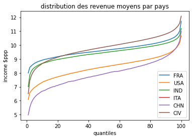

```python
couleur={'FRA':'blue','USA':'red','IND':'grey','ITA':'green','CHN':'yellow','CIV':'black'}
listePays=['FRA','TUR','ITA','CHN','BRA','USA']

for i in range(len(listePays)):
    z= dis_rev_2008.loc[dis_rev_2008['country'] == listePays[i],:].sort_values("income",ascending=False)
    Y=np.log(z['income'])
    x=z['quantile']
    plt.plot(x,Y)

plt.title('distribution des revenue moyens par pays')
plt.xlabel('quantiles')
plt.ylabel('income $ppp')
plt.legend(couleur)
plt.show()
```

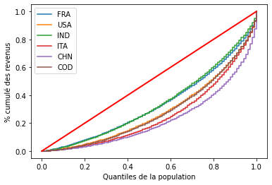

```python
couleur={'FRA':'blue','USA':'red','IND':'grey','ITA':'green','CHN':'yellow','COD':'black'}
listePays=['FRA','TUR','ITA','CHN','BRA','USA']
for i in range(len(listePays)):
    m=dis_rev.loc[(dis_rev['country']==listePays[i]),:]
    mp = m[m['income'] > 0]
    ech = mp['income'].values
    lorenz = np.cumsum(np.sort(ech)) / ech.sum()
    lorenz = np.append([0],lorenz) # La courbe de Lorenz commence à 0

    plt.plot(np.linspace(0,1,len(lorenz)),lorenz,drawstyle='steps-post')



plt.plot([0, 1], [0, 1], 'r-', lw=2, label='Distribution égalitaire')
plt.xlabel('Quantiles de la population')
plt.ylabel('% cumulé des revenus')
plt.legend(couleur)
plt.show()
```

```python
m.head()
```

|  | country | year_survey | quantile | nb_quantiles | income | gdpppp |
| --- | --- | --- | --- | --- | --- | --- |
| 10899 | USA | 2008 | 1 | 100 | 663.4761 | 43261.0 |
| 10900 | USA | 2008 | 2 | 100 | 1698.0868 | 43261.0 |
| 10901 | USA | 2008 | 3 | 100 | 2439.7354 | 43261.0 |
| 10902 | USA | 2008 | 4 | 100 | 3054.2478 | 43261.0 |
| 10903 | USA | 2008 | 5 | 100 | 3627.5483 | 43261.0 |

# Pour chacun de ces pays, représentez l'évolution de l'indice de Gini au fil des ans.

```python
dis_rev.head()
```

|  | country | year_survey | quantile | nb_quantiles | income | gdpppp |
| --- | --- | --- | --- | --- | --- | --- |
| 0 | ALB | 2008 | 1 | 100 | 728.89795 | 7297.0 |
| 1 | ALB | 2008 | 2 | 100 | 916.66235 | 7297.0 |
| 2 | ALB | 2008 | 3 | 100 | 1010.91600 | 7297.0 |
| 3 | ALB | 2008 | 4 | 100 | 1086.90780 | 7297.0 |
| 4 | ALB | 2008 | 5 | 100 | 1132.69970 | 7297.0 |

```python
api_pov_geni.head()
```

|  | Country Name | Country Code | Indicator Name | Indicator Code | 1960 | 1961 | 1962 | 1963 | 1964 | 1965 | ... | 2012 | 2013 | 2014 | 2015 | 2016 | 2017 | 2018 | 2019 | 2020 | Unnamed: 65 |
| --- | --- | --- | --- | --- | --- | --- | --- | --- | --- | --- | --- | --- | --- | --- | --- | --- | --- | --- | --- | --- | --- |
| 0 | Aruba | ABW | Gini index | SI.POV.GINI | NaN | NaN | NaN | NaN | NaN | NaN | ... | NaN | NaN | NaN | NaN | NaN | NaN | NaN | NaN | NaN | NaN |
| 1 | Africa Eastern and Southern | AFE | Gini index | SI.POV.GINI | NaN | NaN | NaN | NaN | NaN | NaN | ... | NaN | NaN | NaN | NaN | NaN | NaN | NaN | NaN | NaN | NaN |
| 2 | Afghanistan | AFG | Gini index | SI.POV.GINI | NaN | NaN | NaN | NaN | NaN | NaN | ... | NaN | NaN | NaN | NaN | NaN | NaN | NaN | NaN | NaN | NaN |
| 3 | Africa Western and Central | AFW | Gini index | SI.POV.GINI | NaN | NaN | NaN | NaN | NaN | NaN | ... | NaN | NaN | NaN | NaN | NaN | NaN | NaN | NaN | NaN | NaN |
| 4 | Angola | AGO | Gini index | SI.POV.GINI | NaN | NaN | NaN | NaN | NaN | NaN | ... | NaN | NaN | NaN | NaN | NaN | NaN | 51.3 | NaN | NaN | NaN |

5 rows × 66 columns

```python
api_pov_geni
```

|  | Country Name | Country Code | Indicator Name | Indicator Code | 1960 | 1961 | 1962 | 1963 | 1964 | 1965 | ... | 2012 | 2013 | 2014 | 2015 | 2016 | 2017 | 2018 | 2019 | 2020 | Unnamed: 65 |
| --- | --- | --- | --- | --- | --- | --- | --- | --- | --- | --- | --- | --- | --- | --- | --- | --- | --- | --- | --- | --- | --- |
| 0 | Aruba | ABW | Gini index | SI.POV.GINI | NaN | NaN | NaN | NaN | NaN | NaN | ... | NaN | NaN | NaN | NaN | NaN | NaN | NaN | NaN | NaN | NaN |
| 1 | Africa Eastern and Southern | AFE | Gini index | SI.POV.GINI | NaN | NaN | NaN | NaN | NaN | NaN | ... | NaN | NaN | NaN | NaN | NaN | NaN | NaN | NaN | NaN | NaN |
| 2 | Afghanistan | AFG | Gini index | SI.POV.GINI | NaN | NaN | NaN | NaN | NaN | NaN | ... | NaN | NaN | NaN | NaN | NaN | NaN | NaN | NaN | NaN | NaN |
| 3 | Africa Western and Central | AFW | Gini index | SI.POV.GINI | NaN | NaN | NaN | NaN | NaN | NaN | ... | NaN | NaN | NaN | NaN | NaN | NaN | NaN | NaN | NaN | NaN |
| 4 | Angola | AGO | Gini index | SI.POV.GINI | NaN | NaN | NaN | NaN | NaN | NaN | ... | NaN | NaN | NaN | NaN | NaN | NaN | 51.3 | NaN | NaN | NaN |
| ... | ... | ... | ... | ... | ... | ... | ... | ... | ... | ... | ... | ... | ... | ... | ... | ... | ... | ... | ... | ... | ... |
| 261 | Kosovo | XKX | Gini index | SI.POV.GINI | NaN | NaN | NaN | NaN | NaN | NaN | ... | 29.0 | 26.3 | 27.3 | 26.5 | 26.7 | 29.0 | NaN | NaN | NaN | NaN |
| 262 | Yemen, Rep. | YEM | Gini index | SI.POV.GINI | NaN | NaN | NaN | NaN | NaN | NaN | ... | NaN | NaN | 36.7 | NaN | NaN | NaN | NaN | NaN | NaN | NaN |
| 263 | South Africa | ZAF | Gini index | SI.POV.GINI | NaN | NaN | NaN | NaN | NaN | NaN | ... | NaN | NaN | 63.0 | NaN | NaN | NaN | NaN | NaN | NaN | NaN |
| 264 | Zambia | ZMB | Gini index | SI.POV.GINI | NaN | NaN | NaN | NaN | NaN | NaN | ... | NaN | NaN | NaN | 57.1 | NaN | NaN | NaN | NaN | NaN | NaN |
| 265 | Zimbabwe | ZWE | Gini index | SI.POV.GINI | NaN | NaN | NaN | NaN | NaN | NaN | ... | NaN | NaN | NaN | NaN | NaN | 44.3 | NaN | 50.3 | NaN | NaN |

266 rows × 66 columns

```python
listePays=['FRA','TUR','ITA','CHN','BRA','USA']
#XKX COD CAF  CIV
```

```python
tab_geni_pays=api_pov_geni[(api_pov_geni['Country Code'].isin (listePays))]
tab_geni_pays
```

|  | Country Name | Country Code | Indicator Name | Indicator Code | 1960 | 1961 | 1962 | 1963 | 1964 | 1965 | ... | 2012 | 2013 | 2014 | 2015 | 2016 | 2017 | 2018 | 2019 | 2020 | Unnamed: 65 |
| --- | --- | --- | --- | --- | --- | --- | --- | --- | --- | --- | --- | --- | --- | --- | --- | --- | --- | --- | --- | --- | --- |
| 29 | Brazil | BRA | Gini index | SI.POV.GINI | NaN | NaN | NaN | NaN | NaN | NaN | ... | 53.4 | 52.7 | 52.0 | 51.9 | 53.3 | 53.3 | 53.9 | 53.5 | 48.9 | NaN |
| 40 | China | CHN | Gini index | SI.POV.GINI | NaN | NaN | NaN | NaN | NaN | NaN | ... | 42.2 | 39.7 | 39.2 | 38.6 | 38.5 | 39.1 | 38.5 | 38.2 | NaN | NaN |
| 77 | France | FRA | Gini index | SI.POV.GINI | NaN | NaN | NaN | NaN | NaN | NaN | ... | 33.1 | 32.5 | 32.3 | 32.7 | 31.9 | 31.6 | 32.4 | NaN | NaN | NaN |
| 116 | Italy | ITA | Gini index | SI.POV.GINI | NaN | NaN | NaN | NaN | NaN | NaN | ... | 35.2 | 34.9 | 34.7 | 35.4 | 35.2 | 35.9 | 35.2 | NaN | NaN | NaN |
| 244 | Turkey | TUR | Gini index | SI.POV.GINI | NaN | NaN | NaN | NaN | NaN | NaN | ... | 40.2 | 40.2 | 41.2 | 42.9 | 41.9 | 41.4 | 41.9 | 41.9 | NaN | NaN |
| 251 | United States | USA | Gini index | SI.POV.GINI | NaN | NaN | NaN | NaN | NaN | NaN | ... | 40.9 | 40.7 | 41.5 | 41.2 | 41.1 | 41.2 | 41.4 | 41.5 | NaN | NaN |

6 rows × 66 columns

```python
tab_geni_pays[["Country Code","2008", "2009", "2010", "2007", "2006", "2011", "2004"]]
```

|  | Country Code | 2008 | 2009 | 2010 | 2007 | 2006 | 2011 | 2004 |
| --- | --- | --- | --- | --- | --- | --- | --- | --- |
| 29 | BRA | 54.0 | 53.7 | NaN | 54.9 | 55.6 | 52.9 | 56.5 |
| 40 | CHN | 43.0 | NaN | 43.7 | NaN | NaN | 42.4 | NaN |
| 77 | FRA | 33.0 | 32.7 | 33.7 | 32.4 | 29.7 | 33.3 | 30.6 |
| 116 | ITA | 33.8 | 33.8 | 34.7 | 32.9 | 33.7 | 35.1 | 34.3 |
| 244 | TUR | 39.0 | 39.0 | 38.8 | 38.4 | 39.6 | 40.0 | 41.3 |
| 251 | USA | 40.8 | 40.6 | 40.0 | 40.8 | 41.4 | 40.9 | 40.3 |

```python
c1=tab_geni_pays.iloc[:,47:64]
```

```python
c2=tab_geni_pays.iloc[:,0:3]
```

```python
c2
```

|  | Country Name | Country Code | Indicator Name |
| --- | --- | --- | --- |
| 29 | Brazil | BRA | Gini index |
| 40 | China | CHN | Gini index |
| 77 | France | FRA | Gini index |
| 116 | Italy | ITA | Gini index |
| 244 | Turkey | TUR | Gini index |
| 251 | United States | USA | Gini index |

```python
geni_plot=pd.concat([c2, c1], axis=1)
geni_plot
```

|  | Country Name | Country Code | Indicator Name | 2003 | 2004 | 2005 | 2006 | 2007 | 2008 | 2009 | 2010 | 2011 | 2012 | 2013 | 2014 | 2015 | 2016 | 2017 | 2018 | 2019 |
| --- | --- | --- | --- | --- | --- | --- | --- | --- | --- | --- | --- | --- | --- | --- | --- | --- | --- | --- | --- | --- |
| 29 | Brazil | BRA | Gini index | 57.6 | 56.5 | 56.3 | 55.6 | 54.9 | 54.0 | 53.7 | NaN | 52.9 | 53.4 | 52.7 | 52.0 | 51.9 | 53.3 | 53.3 | 53.9 | 53.5 |
| 40 | China | CHN | Gini index | NaN | NaN | 40.9 | NaN | NaN | 43.0 | NaN | 43.7 | 42.4 | 42.2 | 39.7 | 39.2 | 38.6 | 38.5 | 39.1 | 38.5 | 38.2 |
| 77 | France | FRA | Gini index | 31.4 | 30.6 | 29.8 | 29.7 | 32.4 | 33.0 | 32.7 | 33.7 | 33.3 | 33.1 | 32.5 | 32.3 | 32.7 | 31.9 | 31.6 | 32.4 | NaN |
| 116 | Italy | ITA | Gini index | 34.9 | 34.3 | 33.8 | 33.7 | 32.9 | 33.8 | 33.8 | 34.7 | 35.1 | 35.2 | 34.9 | 34.7 | 35.4 | 35.2 | 35.9 | 35.2 | NaN |
| 244 | Turkey | TUR | Gini index | 42.2 | 41.3 | 42.6 | 39.6 | 38.4 | 39.0 | 39.0 | 38.8 | 40.0 | 40.2 | 40.2 | 41.2 | 42.9 | 41.9 | 41.4 | 41.9 | 41.9 |
| 251 | United States | USA | Gini index | 40.8 | 40.3 | 41.0 | 41.4 | 40.8 | 40.8 | 40.6 | 40.0 | 40.9 | 40.9 | 40.7 | 41.5 | 41.2 | 41.1 | 41.2 | 41.4 | 41.5 |

```python
geni_plot_dp=geni_plot.drop(['Country Name','Indicator Name'], axis=1)
```

```python
geni_plot_ind=geni_plot_dp.set_index('Country Code')
geni_plot_ind
```

| Country Code | 2003 | 2004 | 2005 | 2006 | 2007 | 2008 | 2009 | 2010 | 2011 | 2012 | 2013 | 2014 | 2015 | 2016 | 2017 | 2018 | 2019 |
| --- | --- | --- | --- | --- | --- | --- | --- | --- | --- | --- | --- | --- | --- | --- | --- | --- | --- |
| BRA | 57.6 | 56.5 | 56.3 | 55.6 | 54.9 | 54.0 | 53.7 | NaN | 52.9 | 53.4 | 52.7 | 52.0 | 51.9 | 53.3 | 53.3 | 53.9 | 53.5 |
| CHN | NaN | NaN | 40.9 | NaN | NaN | 43.0 | NaN | 43.7 | 42.4 | 42.2 | 39.7 | 39.2 | 38.6 | 38.5 | 39.1 | 38.5 | 38.2 |
| FRA | 31.4 | 30.6 | 29.8 | 29.7 | 32.4 | 33.0 | 32.7 | 33.7 | 33.3 | 33.1 | 32.5 | 32.3 | 32.7 | 31.9 | 31.6 | 32.4 | NaN |
| ITA | 34.9 | 34.3 | 33.8 | 33.7 | 32.9 | 33.8 | 33.8 | 34.7 | 35.1 | 35.2 | 34.9 | 34.7 | 35.4 | 35.2 | 35.9 | 35.2 | NaN |
| TUR | 42.2 | 41.3 | 42.6 | 39.6 | 38.4 | 39.0 | 39.0 | 38.8 | 40.0 | 40.2 | 40.2 | 41.2 | 42.9 | 41.9 | 41.4 | 41.9 | 41.9 |
| USA | 40.8 | 40.3 | 41.0 | 41.4 | 40.8 | 40.8 | 40.6 | 40.0 | 40.9 | 40.9 | 40.7 | 41.5 | 41.2 | 41.1 | 41.2 | 41.4 | 41.5 |

```python
geni_plot_ind
```

| Country Code | 2003 | 2004 | 2005 | 2006 | 2007 | 2008 | 2009 | 2010 | 2011 | 2012 | 2013 | 2014 | 2015 | 2016 | 2017 | 2018 | 2019 |
| --- | --- | --- | --- | --- | --- | --- | --- | --- | --- | --- | --- | --- | --- | --- | --- | --- | --- |
| BRA | 57.6 | 56.5 | 56.3 | 55.6 | 54.9 | 54.0 | 53.7 | NaN | 52.9 | 53.4 | 52.7 | 52.0 | 51.9 | 53.3 | 53.3 | 53.9 | 53.5 |
| CHN | NaN | NaN | 40.9 | NaN | NaN | 43.0 | NaN | 43.7 | 42.4 | 42.2 | 39.7 | 39.2 | 38.6 | 38.5 | 39.1 | 38.5 | 38.2 |
| FRA | 31.4 | 30.6 | 29.8 | 29.7 | 32.4 | 33.0 | 32.7 | 33.7 | 33.3 | 33.1 | 32.5 | 32.3 | 32.7 | 31.9 | 31.6 | 32.4 | NaN |
| ITA | 34.9 | 34.3 | 33.8 | 33.7 | 32.9 | 33.8 | 33.8 | 34.7 | 35.1 | 35.2 | 34.9 | 34.7 | 35.4 | 35.2 | 35.9 | 35.2 | NaN |
| TUR | 42.2 | 41.3 | 42.6 | 39.6 | 38.4 | 39.0 | 39.0 | 38.8 | 40.0 | 40.2 | 40.2 | 41.2 | 42.9 | 41.9 | 41.4 | 41.9 | 41.9 |
| USA | 40.8 | 40.3 | 41.0 | 41.4 | 40.8 | 40.8 | 40.6 | 40.0 | 40.9 | 40.9 | 40.7 | 41.5 | 41.2 | 41.1 | 41.2 | 41.4 | 41.5 |

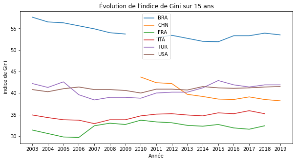

```python
plt.subplots(figsize=(10,5))
for i in range(len(geni_plot_ind)):

    plt.plot(geni_plot_ind.iloc[i] , label = geni_plot_ind.index[i])
plt.title("Évolution de l'indice de Gini sur 15 ans")
plt.xlabel('Année')
plt.ylabel("indice de Gini")
plt.legend()
plt.show()
```

# Classez les pays par indice de Gini.

```python
dis_rev_2008.head()
```

|  | country | year_survey | quantile | nb_quantiles | income | gdpppp |
| --- | --- | --- | --- | --- | --- | --- |
| 0 | ALB | 2008 | 1 | 100 | 728.89795 | 7297.0 |
| 1 | ALB | 2008 | 2 | 100 | 916.66235 | 7297.0 |
| 2 | ALB | 2008 | 3 | 100 | 1010.91600 | 7297.0 |
| 3 | ALB | 2008 | 4 | 100 | 1086.90780 | 7297.0 |
| 4 | ALB | 2008 | 5 | 100 | 1132.69970 | 7297.0 |

```python
listePays_g=dis_rev_2008['country'].unique()
listePays_g
```

```
array(['ALB', 'ARG', 'ARM', 'AUT', 'AZE', 'BEL', 'BGR', 'BLR', 'BOL',
       'BRA', 'CAF', 'CAN', 'CIV', 'COL', 'CRI', 'CYP', 'CZE', 'DEU',
       'DNK', 'DOM', 'ECU', 'ESP', 'EST', 'FIN', 'FJI', 'FRA', 'GBR',
       'GEO', 'GRC', 'HND', 'HRV', 'HUN', 'IRL', 'IRN', 'IRQ', 'ISL',
       'ISR', 'ITA', 'JOR', 'JPN', 'KAZ', 'KGZ', 'KHM', 'KOR', 'XKX',
       'LTU', 'LUX', 'LVA', 'MDA', 'MEX', 'MKD', 'MNE', 'MOZ', 'MRT',
       'NLD', 'NOR', 'PAK', 'PER', 'POL', 'PRT', 'PRY', 'ROU', 'RUS',
       'SLV', 'SRB', 'SVK', 'SVN', 'SWE', 'TUR', 'TWN', 'UKR', 'URY',
       'USA', 'YEM', 'ZAF', 'COD'], dtype=object)
```

```python
for i in range(len(listePays_g)):
    pay=dis_rev_2008.loc[(dis_rev_2008['country']==listePays_g[i]),:]
    ech = pay[pay['income'] > 0]
    ech2 = ech['income'].values
    lorenz2 = np.cumsum(np.sort(ech2)) / ech2.sum()
    lorenz2 = np.append([0],lorenz2) # La courbe de Lorenz commence à 0
    #indice de gini
    n=len(lorenz2)
    AUC = (lorenz2.sum() -lorenz2[-1]/2 -lorenz2[0]/2)/n # Surface sous la courbe de Lorenz. Le premier segment (lorenz[0]) est à moitié en dessous de 0, on le coupe donc en 2, on fait de même pour le dernier segment lorenz[-1] qui est à moitié au dessus de 1.
    S = 0.5 - AUC # surface entre la première bissectrice et le courbe de Lorenz
    gini = 2*S
    dis_rev_2008.loc[dis_rev_2008['country']==listePays_g[i],'gini']=gini
```

```python
 dis_rev_2008
```

|  | country | year_survey | quantile | nb_quantiles | income | gdpppp | gini |
| --- | --- | --- | --- | --- | --- | --- | --- |
| 0 | ALB | 2008 | 1 | 100 | 728.89795 | 7297.00000 | 0.311509 |
| 1 | ALB | 2008 | 2 | 100 | 916.66235 | 7297.00000 | 0.311509 |
| 2 | ALB | 2008 | 3 | 100 | 1010.91600 | 7297.00000 | 0.311509 |
| 3 | ALB | 2008 | 4 | 100 | 1086.90780 | 7297.00000 | 0.311509 |
| 4 | ALB | 2008 | 5 | 100 | 1132.69970 | 7297.00000 | 0.311509 |
| ... | ... | ... | ... | ... | ... | ... | ... |
| 11595 | COD | 2008 | 97 | 100 | 911.78340 | 303.19305 | 0.449502 |
| 11596 | COD | 2008 | 98 | 100 | 1057.80740 | 303.19305 | 0.449502 |
| 11597 | COD | 2008 | 99 | 100 | 1286.60290 | 303.19305 | 0.449502 |
| 11598 | COD | 2008 | 100 | 100 | 2243.12260 | 303.19305 | 0.449502 |
| 11599 | LTU | 2008 | 41 | 100 | 4373.59275 | 17571.00000 | 0.341577 |

7600 rows × 7 columns

```python
geni_gb=pd.DataFrame(dis_rev_2008 .groupby('country')['gini'].agg('mean'))
```

```python
geni_gb.sort_values(by=['gini'],ascending=False)
```

| country | gini |
| --- | --- |
| ZAF | 0.673048 |
| HND | 0.605611 |
| COL | 0.573536 |
| CAF | 0.566071 |
| BOL | 0.565818 |
| ... | ... |
| UKR | 0.262515 |
| SWE | 0.262265 |
| CZE | 0.260261 |
| SVK | 0.254672 |
| SVN | 0.238348 |

76 rows × 1 columns

## la moyenne de l indice de genie

```python
print('la moyenne de l\'indice de genie est:', geni_gb['gini'].mean())
```

```
la moyenne de l'indice de genie est: 0.37361682316510514
```

## les 5 pays ayant l'indice de Gini le plus élevé

```python
print('les 5 pays ayant l\'indice de Gini le plus élevé sont:', geni_gb.sort_values(by=['gini'],ascending=False).head(n=5))
```

```
les 5 pays ayant l'indice de Gini le plus élevé sont:              gini
country
ZAF      0.673048
HND      0.605611
COL      0.573536
CAF      0.566071
BOL      0.565818
```

## les 5 pays ayant l'indice de Gini le plus faible.

```python
print('les 5 pays ayant l\'indice de Gini le plus faible sont:', geni_gb.sort_values(by=['gini'],ascending=True).head(n=5))
```

```
les 5 pays ayant l'indice de Gini le plus faible sont:              gini
country
SVN      0.238348
SVK      0.254672
CZE      0.260261
SWE      0.262265
UKR      0.262515
```

## En quelle position se trouve la France ?

```python
geni_rk=geni_gb.copy()
```

```python
geni_rk['Rank']=geni_rk['gini'].rank()
```

```python
geni_rk.loc[geni_rk.index=='FRA']
```

| country | gini | Rank |
| --- | --- | --- |
| FRA | 0.335739 | 35.0 |

la france se trouve en 35 eme position dans le classement par indice de gini

# Mission3

### Vous baser sur ces coefficients donnés par la Banque mondiale, dans GDIM dataset. Le coefficient d'élasticité est donné pour certains pays, sous le nom d'IGE Income (relative IGM in income).

Dans l'état actuel, nous avons à disposition deux des trois variables explicatives souhaitées : \(m_{j}\) le revenu moyen du pays \(j\) \(G_{j}\) l'indice de Gini du pays \(j\) Il nous manque donc, pour un individu \(i\) , la classe de revenu \(c_{i,parent}\) de ses parents.

```python
elas.head()
```

|  | countryname | wbcode | iso3 | region | incgroup2 | incgroup4 | fragile | survey | year | status | ... | Cores2125_MAcatC1 | Shortfall0611_obs | Shortfall0611_IGP | Shortfall1217_obs | Shortfall1217_IGP | IGEincome | S1 | S2 | S3 | MLD_psu |
| --- | --- | --- | --- | --- | --- | --- | --- | --- | --- | --- | --- | --- | --- | --- | --- | --- | --- | --- | --- | --- | --- |
| 0 | Afghanistan | AFG | AFG | South Asia | Developing economies | Low income | 1 | NRVA | 1980 | Co-residents only | ... | NaN | 25103.0 | 0.086197 | 18054.0 | 0.345224 | NaN | NaN | NaN | NaN | 0.1 |
| 1 | Afghanistan | AFG | AFG | South Asia | Developing economies | Low income | 1 | NRVA | 1980 | Co-residents only | ... | NaN | 12107.0 | 0.083271 | 8538.0 | 0.389952 | NaN | NaN | NaN | NaN | 0.1 |
| 2 | Afghanistan | AFG | AFG | South Asia | Developing economies | Low income | 1 | NRVA | 1980 | Co-residents only | ... | NaN | 12996.0 | 0.089161 | 9516.0 | 0.307687 | NaN | NaN | NaN | NaN | 0.1 |
| 3 | Afghanistan | AFG | AFG | South Asia | Developing economies | Low income | 1 | NRVA | 1980 | Co-residents only | ... | NaN | 25396.0 | 0.050447 | 18387.0 | 0.218062 | NaN | NaN | NaN | NaN | 0.1 |
| 4 | Afghanistan | AFG | AFG | South Asia | Developing economies | Low income | 1 | NRVA | 1980 | Co-residents only | ... | NaN | 12246.0 | 0.047961 | 8677.0 | 0.230909 | NaN | NaN | NaN | NaN | 0.1 |

5 rows × 66 columns

```python
elas.nunique()
```

```
countryname    150
wbcode         150
iso3           150
region           7
incgroup2        2
              ...
IGEincome       75
S1              49
S2              49
S3              49
MLD_psu         45
Length: 66, dtype: int64
```

```python
elas.year.unique()
```

```
array([1980, 1940, 1950, 1960, 1970], dtype=int64)
```

```python
elas.describe()
```

|  | fragile | year | cohort | obs | P1 | P2 | P3 | P4 | P5 | C1 | ... | Cores2125_MAcatC1 | Shortfall0611_obs | Shortfall0611_IGP | Shortfall1217_obs | Shortfall1217_IGP | IGEincome | S1 | S2 | S3 | MLD_psu |
| --- | --- | --- | --- | --- | --- | --- | --- | --- | --- | --- | --- | --- | --- | --- | --- | --- | --- | --- | --- | --- | --- |
| count | 6504.000000 | 6504.000000 | 6504.000000 | 6501.000000 | 6501.000000 | 6501.000000 | 6501.000000 | 6501.000000 | 6501.000000 | 6501.000000 | ... | 845.000000 | 930.000000 | 908.000000 | 1361.00000 | 1337.000000 | 853.000000 | 2845.000000 | 2845.000000 | 2845.000000 | 1225.000000 |
| mean | 0.089483 | 1961.615929 | 1961.615929 | 1286.105830 | 0.361102 | 0.206518 | 0.149553 | 0.188190 | 0.094407 | 0.219147 | ... | 0.612634 | 3395.493548 | 0.079916 | 2134.59662 | 0.172016 | 0.516928 | 0.107122 | 0.053301 | 0.839577 | 0.251861 |
| std | 0.285462 | 14.412033 | 14.412033 | 2291.970266 | 0.345911 | 0.167120 | 0.130607 | 0.184797 | 0.114704 | 0.289676 | ... | 0.180464 | 3995.790251 | 0.103659 | 3265.66739 | 0.139615 | 0.249615 | 0.061527 | 0.034521 | 0.074349 | 0.124587 |
| min | 0.000000 | 1940.000000 | 1940.000000 | 50.000000 | 0.000000 | 0.000000 | 0.000000 | 0.000000 | 0.000000 | 0.000000 | ... | 0.128471 | 1.000000 | -0.593894 | 1.00000 | -0.130202 | 0.112876 | 0.009765 | 0.012044 | 0.649935 | 0.030000 |
| 25% | 0.000000 | 1950.000000 | 1950.000000 | 283.000000 | 0.032625 | 0.065574 | 0.042012 | 0.032678 | 0.013502 | 0.002172 | ... | 0.492818 | 1058.750000 | 0.028097 | 159.00000 | 0.056494 | 0.312578 | 0.057830 | 0.027947 | 0.782551 | 0.160000 |
| 50% | 0.000000 | 1960.000000 | 1960.000000 | 514.000000 | 0.228595 | 0.171569 | 0.116383 | 0.121529 | 0.049856 | 0.040877 | ... | 0.633241 | 2167.000000 | 0.069259 | 1159.00000 | 0.158314 | 0.464077 | 0.098471 | 0.048137 | 0.855454 | 0.210000 |
| 75% | 0.000000 | 1980.000000 | 1980.000000 | 1242.000000 | 0.693064 | 0.311515 | 0.228381 | 0.312678 | 0.135076 | 0.397490 | ... | 0.756912 | 4060.750000 | 0.107568 | 2458.00000 | 0.264241 | 0.689613 | 0.152865 | 0.071971 | 0.899058 | 0.320000 |
| max | 1.000000 | 1980.000000 | 1980.000000 | 29657.000000 | 1.000000 | 0.845898 | 0.777907 | 0.834078 | 0.789995 | 1.000000 | ... | 0.962139 | 29106.000000 | 1.247346 | 25368.00000 | 0.830648 | 1.095440 | 0.292185 | 0.175662 | 0.960701 | 0.680000 |

8 rows × 56 columns

```python
elas.countryname.unique().shape
```

```
(150,)
```

```python
elas.loc[elas['countryname']=='Afghanistan'].head()
```

|  | countryname | wbcode | iso3 | region | incgroup2 | incgroup4 | fragile | survey | year | status | ... | Cores2125_MAcatC1 | Shortfall0611_obs | Shortfall0611_IGP | Shortfall1217_obs | Shortfall1217_IGP | IGEincome | S1 | S2 | S3 | MLD_psu |
| --- | --- | --- | --- | --- | --- | --- | --- | --- | --- | --- | --- | --- | --- | --- | --- | --- | --- | --- | --- | --- | --- |
| 0 | Afghanistan | AFG | AFG | South Asia | Developing economies | Low income | 1 | NRVA | 1980 | Co-residents only | ... | NaN | 25103.0 | 0.086197 | 18054.0 | 0.345224 | NaN | NaN | NaN | NaN | 0.1 |
| 1 | Afghanistan | AFG | AFG | South Asia | Developing economies | Low income | 1 | NRVA | 1980 | Co-residents only | ... | NaN | 12107.0 | 0.083271 | 8538.0 | 0.389952 | NaN | NaN | NaN | NaN | 0.1 |
| 2 | Afghanistan | AFG | AFG | South Asia | Developing economies | Low income | 1 | NRVA | 1980 | Co-residents only | ... | NaN | 12996.0 | 0.089161 | 9516.0 | 0.307687 | NaN | NaN | NaN | NaN | 0.1 |
| 3 | Afghanistan | AFG | AFG | South Asia | Developing economies | Low income | 1 | NRVA | 1980 | Co-residents only | ... | NaN | 25396.0 | 0.050447 | 18387.0 | 0.218062 | NaN | NaN | NaN | NaN | 0.1 |
| 4 | Afghanistan | AFG | AFG | South Asia | Developing economies | Low income | 1 | NRVA | 1980 | Co-residents only | ... | NaN | 12246.0 | 0.047961 | 8677.0 | 0.230909 | NaN | NaN | NaN | NaN | 0.1 |

5 rows × 66 columns

```python
coef_elast=elas[['countryname','wbcode','iso3','region','incgroup4','IGEincome']]
coef_elast.head()
```

|  | countryname | wbcode | iso3 | region | incgroup4 | IGEincome |
| --- | --- | --- | --- | --- | --- | --- |
| 0 | Afghanistan | AFG | AFG | South Asia | Low income | NaN |
| 1 | Afghanistan | AFG | AFG | South Asia | Low income | NaN |
| 2 | Afghanistan | AFG | AFG | South Asia | Low income | NaN |
| 3 | Afghanistan | AFG | AFG | South Asia | Low income | NaN |
| 4 | Afghanistan | AFG | AFG | South Asia | Low income | NaN |

```python
coef_elast.describe()
```

|  | IGEincome |
| --- | --- |
| count | 853.000000 |
| mean | 0.516928 |
| std | 0.249615 |
| min | 0.112876 |
| 25% | 0.312578 |
| 50% | 0.464077 |
| 75% | 0.689613 |
| max | 1.095440 |

```python
coef_elast.value_counts()
```

```
countryname       wbcode  iso3  region                     incgroup4            IGEincome
Albania           ALB     ALB   Europe & Central Asia      Upper middle income  0.815874     12
Korea, Rep.       KOR     KOR   High income                High income          0.394000     12
Peru              PER     PER   Latin America & Caribbean  Upper middle income  0.667000     12
Panama            PAN     PAN   Latin America & Caribbean  Upper middle income  0.966865     12
Pakistan          PAK     PAK   South Asia                 Lower middle income  0.450500     12
                                                                                             ..
Congo, Dem. Rep.  ZAR     COD   Sub-Saharan Africa         Low income           0.707703      6
Benin             BEN     BEN   Sub-Saharan Africa         Low income           0.855116      6
Singapore         SGP     SGP   High income                High income          0.260000      1
Bangladesh        BGD     BGD   South Asia                 Lower middle income  0.538000      1
Luxembourg        LUX     LUX   High income                High income          0.380792      1
Length: 75, dtype: int64
```

```python
coef_elast.isna().sum()
```

```
countryname       0
wbcode            0
iso3              0
region            0
incgroup4         0
IGEincome      5651
dtype: int64
```

```python
coef_elast.isnull().sum()
```

```
countryname       0
wbcode            0
iso3              0
region            0
incgroup4         0
IGEincome      5651
dtype: int64
```

```python
#index_with_nan = coef_elast.index[coef_elast.iloc[:,5].isnull()]
#index_with_nan
```

```python
#coef_elast.drop(index_with_nan,0, inplace=True)
```

```python
coef_elast.head()
```

|  | countryname | wbcode | iso3 | region | incgroup4 | IGEincome |
| --- | --- | --- | --- | --- | --- | --- |
| 0 | Afghanistan | AFG | AFG | South Asia | Low income | NaN |
| 1 | Afghanistan | AFG | AFG | South Asia | Low income | NaN |
| 2 | Afghanistan | AFG | AFG | South Asia | Low income | NaN |
| 3 | Afghanistan | AFG | AFG | South Asia | Low income | NaN |
| 4 | Afghanistan | AFG | AFG | South Asia | Low income | NaN |

### on cherche les coeficient d élasticité manquants et a remplacer les valeurs manquante

```python
elast_gb_reg=coef_elast.groupby(['region','incgroup4']).mean()
elast_gb_reg
```

| region | incgroup4 | IGEincome |
| --- | --- | --- |
| East Asia & Pacific | Lower middle income | 0.527665 |
|  | Upper middle income | 0.469500 |
| Europe & Central Asia | Lower middle income | 0.424817 |
|  | Upper middle income | 0.477171 |
| High income | High income | 0.348050 |
| Latin America & Caribbean | Lower middle income | 0.940737 |
|  | Upper middle income | 0.878852 |
| Middle East & North Africa | Lower middle income | 0.916461 |
|  | Upper middle income | 0.517397 |
| South Asia | Low income | 0.436000 |
|  | Lower middle income | 0.523840 |
|  | Upper middle income | NaN |
| Sub-Saharan Africa | Low income | 0.661654 |
|  | Lower middle income | 0.629976 |
|  | Upper middle income | 0.677000 |

```python
coef_elast.head()
```

|  | countryname | wbcode | iso3 | region | incgroup4 | IGEincome |
| --- | --- | --- | --- | --- | --- | --- |
| 0 | Afghanistan | AFG | AFG | South Asia | Low income | NaN |
| 1 | Afghanistan | AFG | AFG | South Asia | Low income | NaN |
| 2 | Afghanistan | AFG | AFG | South Asia | Low income | NaN |
| 3 | Afghanistan | AFG | AFG | South Asia | Low income | NaN |
| 4 | Afghanistan | AFG | AFG | South Asia | Low income | NaN |

```python
#on remplace les nan de "Upper middle income" south Asia par celui de East Asia & Pacific
nan_ige=0.469500
```

```python
elast_gb_reg_rep=elast_gb_reg.replace(np.nan,0.469500)
elast_gb_reg_rep
```

| region | incgroup4 | IGEincome |
| --- | --- | --- |
| East Asia & Pacific | Lower middle income | 0.527665 |
|  | Upper middle income | 0.469500 |
| Europe & Central Asia | Lower middle income | 0.424817 |
|  | Upper middle income | 0.477171 |
| High income | High income | 0.348050 |
| Latin America & Caribbean | Lower middle income | 0.940737 |
|  | Upper middle income | 0.878852 |
| Middle East & North Africa | Lower middle income | 0.916461 |
|  | Upper middle income | 0.517397 |
| South Asia | Low income | 0.436000 |
|  | Lower middle income | 0.523840 |
|  | Upper middle income | 0.469500 |
| Sub-Saharan Africa | Low income | 0.661654 |
|  | Lower middle income | 0.629976 |
|  | Upper middle income | 0.677000 |

```python
elas_na=coef_elast.loc[coef_elast.IGEincome.isna()]
elas_na.head()
```

|  | countryname | wbcode | iso3 | region | incgroup4 | IGEincome |
| --- | --- | --- | --- | --- | --- | --- |
| 0 | Afghanistan | AFG | AFG | South Asia | Low income | NaN |
| 1 | Afghanistan | AFG | AFG | South Asia | Low income | NaN |
| 2 | Afghanistan | AFG | AFG | South Asia | Low income | NaN |
| 3 | Afghanistan | AFG | AFG | South Asia | Low income | NaN |
| 4 | Afghanistan | AFG | AFG | South Asia | Low income | NaN |

```python
elas_notna=coef_elast.loc[~coef_elast.IGEincome.isna()]
elas_notna.head()
```

|  | countryname | wbcode | iso3 | region | incgroup4 | IGEincome |
| --- | --- | --- | --- | --- | --- | --- |
| 60 | Albania | ALB | ALB | Europe & Central Asia | Upper middle income | 0.815874 |
| 61 | Albania | ALB | ALB | Europe & Central Asia | Upper middle income | 0.815874 |
| 62 | Albania | ALB | ALB | Europe & Central Asia | Upper middle income | 0.815874 |
| 63 | Albania | ALB | ALB | Europe & Central Asia | Upper middle income | 0.815874 |
| 64 | Albania | ALB | ALB | Europe & Central Asia | Upper middle income | 0.815874 |

```python
elas_notna.isna().sum()
```

```
countryname    0
wbcode         0
iso3           0
region         0
incgroup4      0
IGEincome      0
dtype: int64
```

```python
#dis_rev_2008
```

```python
elas_na_mrg=elas_na.merge(elast_gb_reg_rep,
                              left_on=['region','incgroup4'],
                              right_on=['region','incgroup4'],
                              suffixes=('nan', ''))
elas_na_mrgd=elas_na_mrg.drop(columns=['IGEincomenan'])
elas_na_mrgd
```

|  | countryname | wbcode | iso3 | region | incgroup4 | IGEincome |
| --- | --- | --- | --- | --- | --- | --- |
| 0 | Afghanistan | AFG | AFG | South Asia | Low income | 0.4360 |
| 1 | Afghanistan | AFG | AFG | South Asia | Low income | 0.4360 |
| 2 | Afghanistan | AFG | AFG | South Asia | Low income | 0.4360 |
| 3 | Afghanistan | AFG | AFG | South Asia | Low income | 0.4360 |
| 4 | Afghanistan | AFG | AFG | South Asia | Low income | 0.4360 |
| ... | ... | ... | ... | ... | ... | ... |
| 5646 | Maldives | MDV | MDV | South Asia | Upper middle income | 0.4695 |
| 5647 | Maldives | MDV | MDV | South Asia | Upper middle income | 0.4695 |
| 5648 | Maldives | MDV | MDV | South Asia | Upper middle income | 0.4695 |
| 5649 | Maldives | MDV | MDV | South Asia | Upper middle income | 0.4695 |
| 5650 | Maldives | MDV | MDV | South Asia | Upper middle income | 0.4695 |

5651 rows × 6 columns

```python
elas_na_mrg.
```

```
  Input In [355]
    elas_na_mrg.
                ^
SyntaxError: invalid syntax
```

```python
#(elast_cont=elas_na_mrgelas_notna
```

```python
elast_cont = pd.concat([elas_na_mrgd,elas_notna])
elast_cont
```

|  | countryname | wbcode | iso3 | region | incgroup4 | IGEincome |
| --- | --- | --- | --- | --- | --- | --- |
| 0 | Afghanistan | AFG | AFG | South Asia | Low income | 0.436000 |
| 1 | Afghanistan | AFG | AFG | South Asia | Low income | 0.436000 |
| 2 | Afghanistan | AFG | AFG | South Asia | Low income | 0.436000 |
| 3 | Afghanistan | AFG | AFG | South Asia | Low income | 0.436000 |
| 4 | Afghanistan | AFG | AFG | South Asia | Low income | 0.436000 |
| ... | ... | ... | ... | ... | ... | ... |
| 6481 | Congo, Dem. Rep. | ZAR | COD | Sub-Saharan Africa | Low income | 0.707703 |
| 6482 | Congo, Dem. Rep. | ZAR | COD | Sub-Saharan Africa | Low income | 0.707703 |
| 6483 | Congo, Dem. Rep. | ZAR | COD | Sub-Saharan Africa | Low income | 0.707703 |
| 6484 | Congo, Dem. Rep. | ZAR | COD | Sub-Saharan Africa | Low income | 0.707703 |
| 6485 | Congo, Dem. Rep. | ZAR | COD | Sub-Saharan Africa | Low income | 0.707703 |

6504 rows × 6 columns

```python
elast_gb=pd.DataFrame(elast_cont.groupby(['countryname','wbcode','region','incgroup4'])['IGEincome'].agg('mean')).reset_index()
elast_gb
```

|  | countryname | wbcode | region | incgroup4 | IGEincome |
| --- | --- | --- | --- | --- | --- |
| 0 | Afghanistan | AFG | South Asia | Low income | 0.436000 |
| 1 | Albania | ALB | Europe & Central Asia | Upper middle income | 0.544912 |
| 2 | Angola | AGO | Sub-Saharan Africa | Upper middle income | 0.677000 |
| 3 | Argentina | ARG | Latin America & Caribbean | Upper middle income | 0.878852 |
| 4 | Armenia | ARM | Europe & Central Asia | Lower middle income | 0.424817 |
| ... | ... | ... | ... | ... | ... |
| 145 | Venezuela, RB | VEN | Latin America & Caribbean | Upper middle income | 0.878852 |
| 146 | Vietnam | VNM | East Asia & Pacific | Lower middle income | 0.516873 |
| 147 | West Bank and Gaza | WBG | Middle East & North Africa | Lower middle income | 0.916461 |
| 148 | Yemen, Rep. | YEM | Middle East & North Africa | Lower middle income | 0.916461 |
| 149 | Zambia | ZMB | Sub-Saharan Africa | Lower middle income | 0.629976 |

150 rows × 5 columns

```python
elast_gb.isna().sum()
```

```
countryname    0
wbcode         0
region         0
incgroup4      0
IGEincome      0
dtype: int64
```

```python
#jointure des deux tables pour compléter les données de dis_rev avec IGEincome(merge)

dis_elas_gb=dis_rev_2008.merge(elast_gb,
                              left_on=['country'],
                              right_on=['wbcode'])
dis_elas_gb.head()
```

|  | country | year_survey | quantile | nb_quantiles | income | gdpppp | gini | countryname | wbcode | region | incgroup4 | IGEincome |
| --- | --- | --- | --- | --- | --- | --- | --- | --- | --- | --- | --- | --- |
| 0 | ALB | 2008 | 1 | 100 | 728.89795 | 7297.0 | 0.311509 | Albania | ALB | Europe & Central Asia | Upper middle income | 0.544912 |
| 1 | ALB | 2008 | 2 | 100 | 916.66235 | 7297.0 | 0.311509 | Albania | ALB | Europe & Central Asia | Upper middle income | 0.544912 |
| 2 | ALB | 2008 | 3 | 100 | 1010.91600 | 7297.0 | 0.311509 | Albania | ALB | Europe & Central Asia | Upper middle income | 0.544912 |
| 3 | ALB | 2008 | 4 | 100 | 1086.90780 | 7297.0 | 0.311509 | Albania | ALB | Europe & Central Asia | Upper middle income | 0.544912 |
| 4 | ALB | 2008 | 5 | 100 | 1132.69970 | 7297.0 | 0.311509 | Albania | ALB | Europe & Central Asia | Upper middle income | 0.544912 |

```python
dis_elas_gb
```

|  | country | year_survey | quantile | nb_quantiles | income | gdpppp | gini | countryname | wbcode | region | incgroup4 | IGEincome |
| --- | --- | --- | --- | --- | --- | --- | --- | --- | --- | --- | --- | --- |
| 0 | ALB | 2008 | 1 | 100 | 728.89795 | 7297.0 | 0.311509 | Albania | ALB | Europe & Central Asia | Upper middle income | 0.544912 |
| 1 | ALB | 2008 | 2 | 100 | 916.66235 | 7297.0 | 0.311509 | Albania | ALB | Europe & Central Asia | Upper middle income | 0.544912 |
| 2 | ALB | 2008 | 3 | 100 | 1010.91600 | 7297.0 | 0.311509 | Albania | ALB | Europe & Central Asia | Upper middle income | 0.544912 |
| 3 | ALB | 2008 | 4 | 100 | 1086.90780 | 7297.0 | 0.311509 | Albania | ALB | Europe & Central Asia | Upper middle income | 0.544912 |
| 4 | ALB | 2008 | 5 | 100 | 1132.69970 | 7297.0 | 0.311509 | Albania | ALB | Europe & Central Asia | Upper middle income | 0.544912 |
| ... | ... | ... | ... | ... | ... | ... | ... | ... | ... | ... | ... | ... |
| 7295 | ZAF | 2008 | 96 | 100 | 24553.56800 | 9602.0 | 0.673048 | South Africa | ZAF | Sub-Saharan Africa | Upper middle income | 0.677000 |
| 7296 | ZAF | 2008 | 97 | 100 | 28858.03100 | 9602.0 | 0.673048 | South Africa | ZAF | Sub-Saharan Africa | Upper middle income | 0.677000 |
| 7297 | ZAF | 2008 | 98 | 100 | 35750.29000 | 9602.0 | 0.673048 | South Africa | ZAF | Sub-Saharan Africa | Upper middle income | 0.677000 |
| 7298 | ZAF | 2008 | 99 | 100 | 46297.31600 | 9602.0 | 0.673048 | South Africa | ZAF | Sub-Saharan Africa | Upper middle income | 0.677000 |
| 7299 | ZAF | 2008 | 100 | 100 | 82408.55000 | 9602.0 | 0.673048 | South Africa | ZAF | Sub-Saharan Africa | Upper middle income | 0.677000 |

7300 rows × 12 columns

```python
dis_elas_gb.isna().sum()
```

```
country         0
year_survey     0
quantile        0
nb_quantiles    0
income          0
gdpppp          0
gini            0
countryname     0
wbcode          0
region          0
incgroup4       0
IGEincome       0
dtype: int64
```

```python
import scipy.stats as st
import pandas as pd
import numpy as np
from collections import Counter

def generate_incomes(n, pj):
    # On génère les revenus des parents (exprimés en logs) selon une loi normale.
    # La moyenne et variance n'ont aucune incidence sur le résultat final (ie. sur le caclul de la classe de revenu)
    ln_y_parent = st.norm(0,1).rvs(size=n)
    # Génération d'une réalisation du terme d'erreur epsilon
    residues = st.norm(0,1).rvs(size=n)
    return np.exp(pj*ln_y_parent + residues), np.exp(ln_y_parent)

def quantiles(l, nb_quantiles):
    size = len(l)
    l_sorted = l.copy()
    l_sorted = l_sorted.sort_values()
    quantiles = np.round(np.arange(1, nb_quantiles+1, nb_quantiles/size) -0.5 +1./size)
    q_dict = {a:int(b) for a,b in zip(l_sorted,quantiles)}
    return pd.Series([q_dict[e] for e in l])

def compute_quantiles(y_child, y_parents, nb_quantiles):
    y_child = pd.Series(y_child)
    y_parents = pd.Series(y_parents)
    c_i_child = quantiles(y_child, nb_quantiles)
    c_i_parent = quantiles(y_parents, nb_quantiles)
    sample = pd.concat([y_child, y_parents, c_i_child, c_i_parent], axis=1)
    sample.columns = ["y_child", "y_parents", "c_i_child","c_i_parent"]
    return sample

def distribution(counts, nb_quantiles):
    distrib = []
    total = counts["counts"].sum()

    if total == 0 :
        return [0] * nb_quantiles

    for q_p in range(1, nb_quantiles+1):
        subset = counts[counts.c_i_parent == q_p]
        if len(subset):
            nb = subset["counts"].values[0]
            distrib += [nb / total]
        else:
            distrib += [0]
    return distrib

def conditional_distributions(sample, nb_quantiles):
    counts = sample.groupby(["c_i_child","c_i_parent"]).apply(len)
    counts = counts.reset_index()
    counts.columns = ["c_i_child","c_i_parent","counts"]

    mat = []
    for child_quantile in np.arange(nb_quantiles)+1:
        subset = counts[counts.c_i_child == child_quantile]
        mat += [distribution(subset, nb_quantiles)]
    return np.array(mat)

def plot_conditional_distributions(p, cd, nb_quantiles):
    plt.figure()

    # La ligne suivante sert à afficher un graphique en "stack bars", sur ce modèle : https://matplotlib.org/gallery/lines_bars_and_markers/bar_stacked.html
    cumul = np.array([0] * nb_quantiles)

    for i, child_quantile in enumerate(cd):
        plt.bar(np.arange(nb_quantiles)+1, child_quantile, bottom=cumul, width=0.95, label = str(i+1) +"e")
        cumul = cumul + np.array(child_quantile)

    plt.axis([.5, nb_quantiles*1.3 ,0 ,1])
    plt.title("p=" + str(p))
    plt.legend()
    plt.xlabel("quantile parents")
    plt.ylabel("probabilité du quantile enfant")
    plt.show()
```

```python
def proba_cond(c_i_parent, c_i_child, mat):
    return mat[c_i_child, c_i_parent]

pj = 0.9                 # coefficient d'élasticité du pays j
nb_quantiles = 100       # nombre de quantiles (nombre de classes de revenu)
n  = 1000*nb_quantiles   # taille de l'échantillon

y_child, y_parents = generate_incomes(n, pj)
sample = compute_quantiles(y_child, y_parents, nb_quantiles)
cd = conditional_distributions(sample, nb_quantiles)
#plot_conditional_distributions(pj, cd, nb_quantiles) # Cette instruction prendra du temps si nb_quantiles > 10
print(cd)
```

```
[[0.228 0.12  0.085 ... 0.    0.    0.   ]
 [0.148 0.099 0.068 ... 0.    0.    0.   ]
 [0.072 0.075 0.06  ... 0.    0.    0.   ]
 ...
 [0.    0.    0.    ... 0.053 0.076 0.097]
 [0.    0.    0.    ... 0.069 0.096 0.131]
 [0.    0.    0.    ... 0.08  0.113 0.247]]
```

```python
c_i_child = 5
c_i_parent = 8
p = proba_cond(c_i_parent, c_i_child, cd)
print("\nP(c_i_parent = {} | c_i_child = {}, pj = {}) = {}".format(c_i_parent, c_i_child, pj, p))
```

```
P(c_i_parent = 8 | c_i_child = 5, pj = 0.9) = 0.034
```

```python
c_i_child =0
c_i_parent = 2
pj = 0.9
p = proba_cond(c_i_parent, c_i_child, cd)
print("\nP(c_i_parent = {} | c_i_child = {}, pj = {}) = {}".format(c_i_parent, c_i_child, pj, p))
```

```
P(c_i_parent = 2 | c_i_child = 0, pj = 0.9) = 0.085
```

```python
elast_gb_dup=pd.concat([dis_elas_gb]*500)
elast_gb_dup
```

|  | country | year_survey | quantile | nb_quantiles | income | gdpppp | gini | countryname | wbcode | region | incgroup4 | IGEincome |
| --- | --- | --- | --- | --- | --- | --- | --- | --- | --- | --- | --- | --- |
| 0 | ALB | 2008 | 1 | 100 | 728.89795 | 7297.0 | 0.311509 | Albania | ALB | Europe & Central Asia | Upper middle income | 0.544912 |
| 1 | ALB | 2008 | 2 | 100 | 916.66235 | 7297.0 | 0.311509 | Albania | ALB | Europe & Central Asia | Upper middle income | 0.544912 |
| 2 | ALB | 2008 | 3 | 100 | 1010.91600 | 7297.0 | 0.311509 | Albania | ALB | Europe & Central Asia | Upper middle income | 0.544912 |
| 3 | ALB | 2008 | 4 | 100 | 1086.90780 | 7297.0 | 0.311509 | Albania | ALB | Europe & Central Asia | Upper middle income | 0.544912 |
| 4 | ALB | 2008 | 5 | 100 | 1132.69970 | 7297.0 | 0.311509 | Albania | ALB | Europe & Central Asia | Upper middle income | 0.544912 |
| ... | ... | ... | ... | ... | ... | ... | ... | ... | ... | ... | ... | ... |
| 7295 | ZAF | 2008 | 96 | 100 | 24553.56800 | 9602.0 | 0.673048 | South Africa | ZAF | Sub-Saharan Africa | Upper middle income | 0.677000 |
| 7296 | ZAF | 2008 | 97 | 100 | 28858.03100 | 9602.0 | 0.673048 | South Africa | ZAF | Sub-Saharan Africa | Upper middle income | 0.677000 |
| 7297 | ZAF | 2008 | 98 | 100 | 35750.29000 | 9602.0 | 0.673048 | South Africa | ZAF | Sub-Saharan Africa | Upper middle income | 0.677000 |
| 7298 | ZAF | 2008 | 99 | 100 | 46297.31600 | 9602.0 | 0.673048 | South Africa | ZAF | Sub-Saharan Africa | Upper middle income | 0.677000 |
| 7299 | ZAF | 2008 | 100 | 100 | 82408.55000 | 9602.0 | 0.673048 | South Africa | ZAF | Sub-Saharan Africa | Upper middle income | 0.677000 |

3650000 rows × 12 columns

```python
elast_gb_dup.to_csv('data_dup_vers01')
```

```python
dis_rev_2008.head()
```

|  | country | year_survey | quantile | nb_quantiles | income | gdpppp | gini |
| --- | --- | --- | --- | --- | --- | --- | --- |
| 0 | ALB | 2008 | 1 | 100 | 728.89795 | 7297.0 | 0.311509 |
| 1 | ALB | 2008 | 2 | 100 | 916.66235 | 7297.0 | 0.311509 |
| 2 | ALB | 2008 | 3 | 100 | 1010.91600 | 7297.0 | 0.311509 |
| 3 | ALB | 2008 | 4 | 100 | 1086.90780 | 7297.0 | 0.311509 |
| 4 | ALB | 2008 | 5 | 100 | 1132.69970 | 7297.0 | 0.311509 |

```python
elast_gb_dup.loc[elast_gb_dup['country']=='ALB']
```

|  | country | year_survey | quantile | nb_quantiles | income | gdpppp | gini | countryname | wbcode | region | incgroup4 | IGEincome |
| --- | --- | --- | --- | --- | --- | --- | --- | --- | --- | --- | --- | --- |
| 0 | ALB | 2008 | 1 | 100 | 728.89795 | 7297.0 | 0.311509 | Albania | ALB | Europe & Central Asia | Upper middle income | 0.544912 |
| 1 | ALB | 2008 | 2 | 100 | 916.66235 | 7297.0 | 0.311509 | Albania | ALB | Europe & Central Asia | Upper middle income | 0.544912 |
| 2 | ALB | 2008 | 3 | 100 | 1010.91600 | 7297.0 | 0.311509 | Albania | ALB | Europe & Central Asia | Upper middle income | 0.544912 |
| 3 | ALB | 2008 | 4 | 100 | 1086.90780 | 7297.0 | 0.311509 | Albania | ALB | Europe & Central Asia | Upper middle income | 0.544912 |
| 4 | ALB | 2008 | 5 | 100 | 1132.69970 | 7297.0 | 0.311509 | Albania | ALB | Europe & Central Asia | Upper middle income | 0.544912 |
| ... | ... | ... | ... | ... | ... | ... | ... | ... | ... | ... | ... | ... |
| 95 | ALB | 2008 | 96 | 100 | 6231.09960 | 7297.0 | 0.311509 | Albania | ALB | Europe & Central Asia | Upper middle income | 0.544912 |
| 96 | ALB | 2008 | 97 | 100 | 6822.31840 | 7297.0 | 0.311509 | Albania | ALB | Europe & Central Asia | Upper middle income | 0.544912 |
| 97 | ALB | 2008 | 98 | 100 | 7775.89100 | 7297.0 | 0.311509 | Albania | ALB | Europe & Central Asia | Upper middle income | 0.544912 |
| 98 | ALB | 2008 | 99 | 100 | 9351.75100 | 7297.0 | 0.311509 | Albania | ALB | Europe & Central Asia | Upper middle income | 0.544912 |
| 99 | ALB | 2008 | 100 | 100 | 17754.32400 | 7297.0 | 0.311509 | Albania | ALB | Europe & Central Asia | Upper middle income | 0.544912 |

50000 rows × 12 columns

```python
elast_gb_dup.loc[elast_gb_dup['wbcode']=='AFG']
```

|  | country | year_survey | quantile | nb_quantiles | income | gdpppp | gini | countryname | wbcode | region | incgroup4 | IGEincome |
| --- | --- | --- | --- | --- | --- | --- | --- | --- | --- | --- | --- | --- |

```python
 elast_gb_dup.isna().sum()
```

```
country         0
year_survey     0
quantile        0
nb_quantiles    0
income          0
gdpppp          0
gini            0
countryname     0
wbcode          0
region          0
incgroup4       0
IGEincome       0
dtype: int64
```

```python
 elast_gb_dup.isnull().sum()
```

```
country         0
year_survey     0
quantile        0
nb_quantiles    0
income          0
gdpppp          0
gini            0
countryname     0
wbcode          0
region          0
incgroup4       0
IGEincome       0
dtype: int64
```

```python
listePays_p=elast_gb_dup['countryname'].unique()

l_proba=[]
data=[]
df_p=pd.DataFrame(data=data)
df_p['pays']=0
df_p['c_i_child']=0
df_p['c_i_parent']=0

#df = pd.DataFrame(data=data,columns=columns)

for i in listePays_p:

    pj = elast_gb_dup.loc[elast_gb_dup['countryname'] ==i,'IGEincome'].iloc[0]
    # coefficient d'élasticité du pays j
    nb_quantiles = 100
    # nombre de quantiles (nombre de classes de revenu)
    n  = 50000 # taille de l'échantillon

    y_child, y_parents = generate_incomes(n, pj)


    sample = compute_quantiles(y_child, y_parents, nb_quantiles)

    cd = conditional_distributions(sample, nb_quantiles)

#plot_conditional_distributions(pj, cd, nb_quantiles) # Cette instruction prendra du temps si nb_quantiles > 10
    for c_i_child in range(100):
        for c_i_parent in range(100):
            p = proba_cond(c_i_parent, c_i_child, cd)

            #print("\nP(c_i_parent = {} | c_i_child = {}, pj = {}) = {}".format(c_i_parent, c_i_child,pj,p))
            l_proba.extend([c_i_parent+1]*(int(p*500)))
            #elast_gb_dup.loc[(elast_gb_dup['countryname'] == i), 'c_i_parent'] = c_i_parent

            df_p2=pd.DataFrame(l_proba)
            df_p2['c_i_parent']=c_i_parent+1
            df_p2['pays']=i
            df_p2['c_i_child']=c_i_child+1
            df_p= pd.concat([df_p,df_p2])
            l_proba=[]
```

```python
df_p
```

```
---------------------------------------------------------------------------
NameError                                 Traceback (most recent call last)
Input In [375], in <cell line: 1>()
----> 1 df_p

NameError: name 'df_p' is not defined
```

```python
elast_gb_dup.head()
```

|  | country | year_survey | quantile | nb_quantiles | income | gdpppp | gini | countryname | wbcode | region | incgroup4 | IGEincome |
| --- | --- | --- | --- | --- | --- | --- | --- | --- | --- | --- | --- | --- |
| 0 | ALB | 2008 | 1 | 100 | 728.89795 | 7297.0 | 0.311509 | Albania | ALB | Europe & Central Asia | Upper middle income | 0.544912 |
| 1 | ALB | 2008 | 2 | 100 | 916.66235 | 7297.0 | 0.311509 | Albania | ALB | Europe & Central Asia | Upper middle income | 0.544912 |
| 2 | ALB | 2008 | 3 | 100 | 1010.91600 | 7297.0 | 0.311509 | Albania | ALB | Europe & Central Asia | Upper middle income | 0.544912 |
| 3 | ALB | 2008 | 4 | 100 | 1086.90780 | 7297.0 | 0.311509 | Albania | ALB | Europe & Central Asia | Upper middle income | 0.544912 |
| 4 | ALB | 2008 | 5 | 100 | 1132.69970 | 7297.0 | 0.311509 | Albania | ALB | Europe & Central Asia | Upper middle income | 0.544912 |

```python
elast_gb_dp=elast_gb_dup[['countryname','quantile','income','gini']]
elast_gb_dp.head()
```

|  | countryname | quantile | income | gini |
| --- | --- | --- | --- | --- |
| 0 | Albania | 1 | 728.89795 | 0.311509 |
| 1 | Albania | 2 | 916.66235 | 0.311509 |
| 2 | Albania | 3 | 1010.91600 | 0.311509 |
| 3 | Albania | 4 | 1086.90780 | 0.311509 |
| 4 | Albania | 5 | 1132.69970 | 0.311509 |

```python
elast_gb_ren = elast_gb_dp.rename(columns = {"countryname":"pays",
                                  "quantile":"c_i_child"})
elast_gb_ren.head()
```

|  | pays | c_i_child | income | gini |
| --- | --- | --- | --- | --- |
| 0 | Albania | 1 | 728.89795 | 0.311509 |
| 1 | Albania | 2 | 916.66235 | 0.311509 |
| 2 | Albania | 3 | 1010.91600 | 0.311509 |
| 3 | Albania | 4 | 1086.90780 | 0.311509 |
| 4 | Albania | 5 | 1132.69970 | 0.311509 |

```python
elast_gb_ren=elast_gb_ren.sort_values(by=['pays','c_i_child']).reset_index()
elast_gb_ren.head()
```

|  | index | pays | c_i_child | income | gini |
| --- | --- | --- | --- | --- | --- |
| 0 | 0 | Albania | 1 | 728.89795 | 0.311509 |
| 1 | 0 | Albania | 1 | 728.89795 | 0.311509 |
| 2 | 0 | Albania | 1 | 728.89795 | 0.311509 |
| 3 | 0 | Albania | 1 | 728.89795 | 0.311509 |
| 4 | 0 | Albania | 1 | 728.89795 | 0.311509 |

```python
elast_gb_ord=elast_gb_ren[['pays','c_i_child','income','gini']]
elast_gb_ord.head(3).dtypes
```

```
pays          object
c_i_child      int64
income       float64
gini         float64
dtype: object
```

```python
pd.options.mode.chained_assignment = None
```

```python
elast_gb_ord['c_i_child']=elast_gb_ord['c_i_child'].apply(lambda _: str(_))
elast_gb_ord.dtypes
```

```
pays          object
c_i_child     object
income       float64
gini         float64
dtype: object
```

```python
#df_p.to_csv("p7_proba.csv")
```

```python
elast_gb_proba= pd.read_csv('D:\\Aopenclassroom\\p7/p7_proba.csv')
elast_gb_proba.head(3)
```

|  | Unnamed: 0 | pays | c_i_child | c_i_parent | 0 |
| --- | --- | --- | --- | --- | --- |
| 0 | 0 | Albania | 1 | 1 | 1.0 |
| 1 | 1 | Albania | 1 | 1 | 1.0 |
| 2 | 2 | Albania | 1 | 1 | 1.0 |

```python
elast_gb_prob=elast_gb_proba[['pays','c_i_child','c_i_parent']]
elast_gb_prob.head(3)
```

|  | pays | c_i_child | c_i_parent |
| --- | --- | --- | --- |
| 0 | Albania | 1 | 1 |
| 1 | Albania | 1 | 1 |
| 2 | Albania | 1 | 1 |

```python
elast_gb_prob['c_i_child']=elast_gb_prob['c_i_child'].apply(lambda _: str(_))
elast_gb_prob.dtypes
```

```
pays          object
c_i_child     object
c_i_parent     int64
dtype: object
```

```python
elast_gb_prob['c_i_child']=elast_gb_prob['c_i_child'].apply(lambda _: str(_))
elast_gb_prob.dtypes
```

```
pays          object
c_i_child     object
c_i_parent     int64
dtype: object
```

```python
elast_gb_ord=elast_gb_ord.drop_duplicates()
```

```python
elast_gb_mrg=elast_gb_prob.merge(elast_gb_ord,how='left')
elast_gb_mrg
```

|  | pays | c_i_child | c_i_parent | income | gini |
| --- | --- | --- | --- | --- | --- |
| 0 | Albania | 1 | 1 | 728.89795 | 0.311509 |
| 1 | Albania | 1 | 1 | 728.89795 | 0.311509 |
| 2 | Albania | 1 | 1 | 728.89795 | 0.311509 |
| 3 | Albania | 1 | 1 | 728.89795 | 0.311509 |
| 4 | Albania | 1 | 1 | 728.89795 | 0.311509 |
| ... | ... | ... | ... | ... | ... |
| 3649995 | South Africa | 100 | 100 | 82408.55000 | 0.673048 |
| 3649996 | South Africa | 100 | 100 | 82408.55000 | 0.673048 |
| 3649997 | South Africa | 100 | 100 | 82408.55000 | 0.673048 |
| 3649998 | South Africa | 100 | 100 | 82408.55000 | 0.673048 |
| 3649999 | South Africa | 100 | 100 | 82408.55000 | 0.673048 |

3650000 rows × 5 columns

## préparer les données pour la mission4

```python
# Création d'un dataframe avec la variable revenu moyen du pays
elast_gb_m=elast_gb_mrg.groupby(by='pays').mean()
elast_gb_m.reset_index(inplace=True)
```

```python
elast_gb_mean=pd.DataFrame(elast_gb_m)
elast_gb_mean
```

|  | pays | c_i_parent | income | gini |
| --- | --- | --- | --- | --- |
| 0 | Albania | 50.5 | 2994.829902 | 0.311509 |
| 1 | Argentina | 50.5 | 5847.884654 | 0.455348 |
| 2 | Armenia | 50.5 | 1628.382785 | 0.270404 |
| 3 | Austria | 50.5 | 16637.600204 | 0.285425 |
| 4 | Azerbaijan | 50.5 | 2357.429023 | 0.319130 |
| ... | ... | ... | ... | ... |
| 68 | Ukraine | 50.5 | 3349.388306 | 0.262515 |
| 69 | United Kingdom | 50.5 | 21709.604470 | 0.345923 |
| 70 | United States | 50.5 | 25503.581661 | 0.437425 |
| 71 | Uruguay | 50.5 | 5290.784920 | 0.465159 |
| 72 | Yemen, Rep. | 50.5 | 1042.635870 | 0.380358 |

73 rows × 4 columns

```python
# Création d'un dataframe avec la variable revenu moyen du pays

elast_gb_mean=elast_gb_mean[['pays','income']]
#on renome la variable income en revenue moyen du pays
elast_gb_mean=elast_gb_mean.rename({'income':'revenue_moyen'},
                         axis=1)
elast_gb_mean.head(3)
```

|  | pays | revenue_moyen |
| --- | --- | --- |
| 0 | Albania | 2994.829902 |
| 1 | Argentina | 5847.884654 |
| 2 | Armenia | 1628.382785 |

```python
#on join les deux tables pour avoir les deux informations income et revenue moyen du pays
elast_gb_final=elast_gb_mrg.merge(elast_gb_mean, how='left', on='pays')
elast_gb_final
```

|  | pays | c_i_child | c_i_parent | income | gini | revenue_moyen |
| --- | --- | --- | --- | --- | --- | --- |
| 0 | Albania | 1 | 1 | 728.89795 | 0.311509 | 2994.829902 |
| 1 | Albania | 1 | 1 | 728.89795 | 0.311509 | 2994.829902 |
| 2 | Albania | 1 | 1 | 728.89795 | 0.311509 | 2994.829902 |
| 3 | Albania | 1 | 1 | 728.89795 | 0.311509 | 2994.829902 |
| 4 | Albania | 1 | 1 | 728.89795 | 0.311509 | 2994.829902 |
| ... | ... | ... | ... | ... | ... | ... |
| 3649995 | South Africa | 100 | 100 | 82408.55000 | 0.673048 | 5617.904880 |
| 3649996 | South Africa | 100 | 100 | 82408.55000 | 0.673048 | 5617.904880 |
| 3649997 | South Africa | 100 | 100 | 82408.55000 | 0.673048 | 5617.904880 |
| 3649998 | South Africa | 100 | 100 | 82408.55000 | 0.673048 | 5617.904880 |
| 3649999 | South Africa | 100 | 100 | 82408.55000 | 0.673048 | 5617.904880 |

3650000 rows × 6 columns

```python
elast_gb_final['log_revenue_moyen']=np.log(elast_gb_final['revenue_moyen'])
```

```python
elast_gb_final['log_income']=np.log(elast_gb_final['income'])
```

```python
elast_gb_final
```

|  | pays | c_i_child | c_i_parent | income | gini | revenue_moyen | log_revenue_moyen | log_income |
| --- | --- | --- | --- | --- | --- | --- | --- | --- |
| 0 | Albania | 1 | 1 | 728.89795 | 0.311509 | 2994.829902 | 8.004643 | 6.591534 |
| 1 | Albania | 1 | 1 | 728.89795 | 0.311509 | 2994.829902 | 8.004643 | 6.591534 |
| 2 | Albania | 1 | 1 | 728.89795 | 0.311509 | 2994.829902 | 8.004643 | 6.591534 |
| 3 | Albania | 1 | 1 | 728.89795 | 0.311509 | 2994.829902 | 8.004643 | 6.591534 |
| 4 | Albania | 1 | 1 | 728.89795 | 0.311509 | 2994.829902 | 8.004643 | 6.591534 |
| ... | ... | ... | ... | ... | ... | ... | ... | ... |
| 3649995 | South Africa | 100 | 100 | 82408.55000 | 0.673048 | 5617.904880 | 8.633714 | 11.319444 |
| 3649996 | South Africa | 100 | 100 | 82408.55000 | 0.673048 | 5617.904880 | 8.633714 | 11.319444 |
| 3649997 | South Africa | 100 | 100 | 82408.55000 | 0.673048 | 5617.904880 | 8.633714 | 11.319444 |
| 3649998 | South Africa | 100 | 100 | 82408.55000 | 0.673048 | 5617.904880 | 8.633714 | 11.319444 |
| 3649999 | South Africa | 100 | 100 | 82408.55000 | 0.673048 | 5617.904880 | 8.633714 | 11.319444 |

3650000 rows × 8 columns

```python
elast_gb_final.to_csv("p7_elast_gb_final.csv")
```

```python
elast_gb_final.head(3)
```

|  | pays | c_i_child | c_i_parent | income | gini | revenue_moyen | log_revenue_moyen | log_income |
| --- | --- | --- | --- | --- | --- | --- | --- | --- |
| 0 | Albania | 1 | 1 | 728.89795 | 0.311509 | 2994.829902 | 8.004643 | 6.591534 |
| 1 | Albania | 1 | 1 | 728.89795 | 0.311509 | 2994.829902 | 8.004643 | 6.591534 |
| 2 | Albania | 1 | 1 | 728.89795 | 0.311509 | 2994.829902 | 8.004643 | 6.591534 |

```python
elast_gb_fini=elast_gb_final[['pays','income','revenue_moyen','gini','c_i_parent']]
elast_gb_fini.to_csv("p7_elast_gb_fini.csv")
```

```python
elast_gb_fini.head()
```

|  | pays | income | revenue_moyen | gini | c_i_parent |
| --- | --- | --- | --- | --- | --- |
| 0 | Albania | 728.89795 | 2994.829902 | 0.311509 | 1 |
| 1 | Albania | 728.89795 | 2994.829902 | 0.311509 | 1 |
| 2 | Albania | 728.89795 | 2994.829902 | 0.311509 | 1 |
| 3 | Albania | 728.89795 | 2994.829902 | 0.311509 | 1 |
| 4 | Albania | 728.89795 | 2994.829902 | 0.311509 | 1 |

```python
elast_gb_fini_log=elast_gb_final[['pays','log_income','log_revenue_moyen','gini','c_i_parent']]
elast_gb_fini_log.to_csv("p7_elast_gb_fini_log.csv")
```

```python
elast_gb_fini_log
```

|  | pays | log_income | log_revenue_moyen | gini | c_i_parent |
| --- | --- | --- | --- | --- | --- |
| 0 | Albania | 6.591534 | 8.004643 | 0.311509 | 1 |
| 1 | Albania | 6.591534 | 8.004643 | 0.311509 | 1 |
| 2 | Albania | 6.591534 | 8.004643 | 0.311509 | 1 |
| 3 | Albania | 6.591534 | 8.004643 | 0.311509 | 1 |
| 4 | Albania | 6.591534 | 8.004643 | 0.311509 | 1 |
| ... | ... | ... | ... | ... | ... |
| 3649995 | South Africa | 11.319444 | 8.633714 | 0.673048 | 100 |
| 3649996 | South Africa | 11.319444 | 8.633714 | 0.673048 | 100 |
| 3649997 | South Africa | 11.319444 | 8.633714 | 0.673048 | 100 |
| 3649998 | South Africa | 11.319444 | 8.633714 | 0.673048 | 100 |
| 3649999 | South Africa | 11.319444 | 8.633714 | 0.673048 | 100 |

3650000 rows × 5 columns